# FitBit Fitness Track Data

by Mercy F Nyambura Kariuki

-

-

-

-

## How Can a Wellness Technology Company Play It Smart?

# Introduction

Welcome to the Bellabeat data analysis case study!

In this case study, you will perform many real-world tasks of a junior data analyst. You will imagine you are working for Bellabeat, a high-tech manufacturer of health-focused products for women, andmeet different characters and team members.

Along the way, the Case Study Roadmap tables — including guiding questions and key tasks — will help you stay on the right path.

## Scenario

You are a junior data analyst working on the marketing analyst team at Bellabeat, a high-tech manufacturer of health-focused products for women. Bellabeat is a successful small company, but they have the potential to become a larger player in the global smart device market. Urška Sršen, cofounder and Chief Creative Officer of Bellabeat, believes that analyzing smart device fitness data could help unlock new growth opportunities for the company. You have been asked to focus on one of Bellabeat’s products and analyze smart device data to gain insight into how consumers are using their smart devices.

The insights you discover will then help guide marketing strategy for the company. You will present your analysis to the Bellabeat executive team along with your high-level recommendations for Bellabeat’s marketing strategy.

## Characters and products

- **Characters**

  ○ Urška Sršen: Bellabeat’s cofounder and Chief Creative Officer

  ○ Sando Mur: Mathematician and Bellabeat’s cofounder; key member of the Bellabeat executive team

  ○ Bellabeat marketing analytics team: A team of data analysts responsible for collecting, analyzing, and reporting data that helps guide Bellabeat’s marketing strategy. You joined this team six months ago and have been busy learning about Bellabeat’’s mission and business goals — as well as how you, as a junior data analyst, can help Bellabeat achieve them.
- **Products**

  ○ Bellabeat app: The Bellabeat app provides users with health data related to their activity, sleep, stress, menstrual cycle, and mindfulness habits. This data can help users better understand their current habits and make healthy decisions. The Bellabeat app connects to their line of smart wellness products.

  ○ Leaf: Bellabeat’s classic wellness tracker can be worn as a bracelet, necklace, or clip. The Leaf tracker connects to the Bellabeat app to track activity, sleep, and stress.

  ○ Time: This wellness watch combines the timeless look of a classic timepiece with smart technology to track user activity, sleep, and stress. The Time watch connects to the Bellabeat app to provide you with insights into your daily wellness.

  ○ Spring: This is a water bottle that tracks daily water intake using smart technology to ensure that you are appropriately hydrated throughout the day. The Spring bottle connects to the Bellabeat app to track your hydration levels.

  ○ Bellabeat membership: Bellabeat also offers a subscription-based membership program for users. Membership gives users 24/7 access to fully personalized guidance on nutrition, activity, sleep, health and beauty, and mindfulness based on their lifestyle and goals.

## About the company

Urška Sršen and Sando Mur founded Bellabeat, a high-tech company that manufactures health-focused smart products. Sršen used her background as an artist to develop beautifully designed technology that informs and inspires women around the world. Collecting data on activity, sleep, stress, and reproductive health has allowed Bellabeat to empower women with knowledge about their own health and habits. Since it was founded in 2013, Bellabeat has grown rapidly and quickly positioned itself as a tech-driven wellness company for women. By 2016, Bellabeat had opened offices around the world and launched multiple products. Bellabeat products became available through a growing number of online retailers in addition to their own e-commerce channel on their website. The company has invested in traditional advertising media, such as radio, out-of-home billboards, print, and television, but focuses on digital marketing extensively. Bellabeat invests year-round in Google Search, maintaining active Facebook and Instagram pages, and consistently engages consumers on Twitter. Additionally, Bellabeat runs video ads on Youtube and display ads on the Google Display Network to support campaigns around key marketing dates.

Sršen knows that an analysis of Bellabeat’s available consumer data would reveal more opportunities for growth. She has asked the marketing analytics team to focus on a Bellabeat product and analyze smart device usage data in order to gain insight into how people are already using their smart devices. Then, using this information, she would like high-level recommendations for how these trends can inform Bellabeat marketing strategy.

## Prepare

Sršen encourages you to use public data that explores smart device users’ daily habits. She points you to a specific data set:

- [FitBit Fitness Tracker Data](https://www.kaggle.com/datasets/arashnic/fitbit) (CC0: Public Domain, dataset made available through Mobius): This Kaggle data set contains personal fitness tracker from thirty fitbit users. Thirty eligible Fitbit users consented to the submission of personal tracker data, including minute-level output for physical activity, heart rate, and sleep monitoring. It includes information about daily activity, steps, and heart rate that can be used to explore users’ habits.

# Stage 1: Data processing

```python
import numpy as np
import pandas as pd
import seaborn as sns
import matplotlib.pyplot as plt

import datetime as dt
import calendar

import warnings

%matplotlib inline

warnings.filterwarnings("ignore")
```

```python
activity=pd.read_csv("C:/Users/kariu/OneDrive/Desktop/Data Science/Google_Capstone_Project/FitBit Fitness Tracker Data/Fitabase Data/dailyActivity_merged.csv")
HourlyCalories=pd.read_csv('C:/Users/kariu/OneDrive/Desktop/Data Science/Google_Capstone_Project/FitBit Fitness Tracker Data/Fitabase Data/hourlyCalories_merged.csv')
WeightInfo = pd.read_csv('C:/Users/kariu/OneDrive/Desktop/Data Science/Google_Capstone_Project/FitBit Fitness Tracker Data/Fitabase Data/weightLogInfo_merged.csv')
SleepDay=sleep_day = pd.read_csv('C:/Users/kariu/OneDrive/Desktop/Data Science/Google_Capstone_Project/FitBit Fitness Tracker Data/Fitabase Data/sleepDay_merged.csv')
```

```python
activity.duplicated().sum()
```

```
0
```

```python
activity.isnull().sum()
```

```
Id                          0
ActivityDate                0
TotalSteps                  0
TotalDistance               0
TrackerDistance             0
LoggedActivitiesDistance    0
VeryActiveDistance          0
ModeratelyActiveDistance    0
LightActiveDistance         0
SedentaryActiveDistance     0
VeryActiveMinutes           0
FairlyActiveMinutes         0
LightlyActiveMinutes        0
SedentaryMinutes            0
Calories                    0
dtype: int64
```

```python
activity.nunique()
```

```
Id                           33
ActivityDate                 31
TotalSteps                  842
TotalDistance               615
TrackerDistance             613
LoggedActivitiesDistance     19
VeryActiveDistance          333
ModeratelyActiveDistance    211
LightActiveDistance         491
SedentaryActiveDistance       9
VeryActiveMinutes           122
FairlyActiveMinutes          81
LightlyActiveMinutes        335
SedentaryMinutes            549
Calories                    734
dtype: int64
```

```python
activity.sample(3)
```

|  | Id | ActivityDate | TotalSteps | TotalDistance | TrackerDistance | LoggedActivitiesDistance | VeryActiveDistance | ModeratelyActiveDistance | LightActiveDistance | SedentaryActiveDistance | VeryActiveMinutes | FairlyActiveMinutes | LightlyActiveMinutes | SedentaryMinutes | Calories |
| --- | --- | --- | --- | --- | --- | --- | --- | --- | --- | --- | --- | --- | --- | --- | --- |
| 593 | 5577150313 | 5/8/2016 | 0 | 0.00 | 0.00 | 0.0 | 0.00 | 0.00 | 0.00 | 0.0 | 0 | 0 | 0 | 1440 | 1819 |
| 879 | 8583815059 | 5/12/2016 | 0 | 0.00 | 0.00 | 0.0 | 0.00 | 0.00 | 0.00 | 0.0 | 0 | 0 | 0 | 1440 | 0 |
| 708 | 6962181067 | 5/10/2016 | 15448 | 10.21 | 10.21 | 0.0 | 3.47 | 1.75 | 4.99 | 0.0 | 62 | 34 | 275 | 626 | 2361 |

```python
activity.info()
```

```
<class 'pandas.core.frame.DataFrame'>
RangeIndex: 940 entries, 0 to 939
Data columns (total 15 columns):
 #   Column                    Non-Null Count  Dtype
---  ------                    --------------  -----
 0   Id                        940 non-null    int64
 1   ActivityDate              940 non-null    object
 2   TotalSteps                940 non-null    int64
 3   TotalDistance             940 non-null    float64
 4   TrackerDistance           940 non-null    float64
 5   LoggedActivitiesDistance  940 non-null    float64
 6   VeryActiveDistance        940 non-null    float64
 7   ModeratelyActiveDistance  940 non-null    float64
 8   LightActiveDistance       940 non-null    float64
 9   SedentaryActiveDistance   940 non-null    float64
 10  VeryActiveMinutes         940 non-null    int64
 11  FairlyActiveMinutes       940 non-null    int64
 12  LightlyActiveMinutes      940 non-null    int64
 13  SedentaryMinutes          940 non-null    int64
 14  Calories                  940 non-null    int64
dtypes: float64(7), int64(7), object(1)
memory usage: 110.3+ KB
```

We have in total 15 different columns and 940 entries. The columns contain object data types, integers or floating point numbers.

From the above observation, noted that

1. There is no typo, Null or missing values.
2. Data frame has 940 rows and 15 columns.
3. *ActivityDate* is wrongly classified as `object` dtype and has to be converted to `datetime64` dtype and split to days, months and years.
4. There are 33 unique IDs, instead of 30 unique IDs as expected from 30 fitness tracker users.

The following data manipulation is performed:

1. Convert *ActivityDate* to `datatime64` dtype.
2. Convert format of *ActivityDate* to `yyyy-mm-dd`.
3. Create new column *DayOfTheWeek* by separating the date into day of the week for further analysis.
4. Create new column *TotalMins* being the sum of *VeryActiveMinutes*, *FairlyActiveMinutes*, *LightlyActiveMinutes* and *SedentaryMinutes*.
5. Create new column *TotalHours* by converting new column in #4 to number of hours.
6. Rearrange and rename columns.

Converting *ActivityDate* from `object` to `datatime64` dtype and converting format of *ActivityDate* to `yyyy-mm-dd`. Then, printing head to confirm whether it has been updated to `datatime64` dtype and dates to `yyyy-mm-dd`.

### Units

Unfortunately we don't know whether the distance is measured in km or miles which is affected by the device settings. If all distances were recorded in either km or miles, there wouldn't be any problem since the ratio between a measurement and the reference point are independent from what actual units are used. We could try to check if similar amounts of total steps equal similar amounts of calories. But since burnt calories are affected by gender, age, weight and other factors, which we don't know, it's impossible to analyze.

Calories seem to refer to total daily calories burned incl. those at rest. The distinction between sedentary, lightly, fairly and very active will be explained in the following.

### Contextual information - MET

Before heading over to the actual analysis, I would like to provide some contextual information about MET, which will affect the interpretation of different activity intensities later:

**MET** stands for **metabolic equivalents**.

- 1 MET is defined as the energy consumed by your body while sitting at rest. The higher the MET, the more intense the exercise.
- According to FitBit, the activity data has been split into four categories:
  > - sedentary (>1.5 METs)
  > - light (1,5-3 METs)
  > - fairly active (3-6 METs) and
  > - very active (>6 METs).
- Walking roughly corresponds to 3 METs (URL: https://community.fitbit.com/t5/Web-API-Development/Daily-Activity-Summary-Data-Definition-Questions/td-p/3087077, https://help.fitbit.com/articles/en_US/Help_article/1379.htm)

# Stage 2: Data Wrangling

- **Convert "ActivityDate" to datatime64 dtype and format to yyyy-mm-dd**

```python
activity["ActivityDate"] = pd.to_datetime(activity["ActivityDate"], format="%m/%d/%Y")
```

```python
activity.info()
```

```
<class 'pandas.core.frame.DataFrame'>
RangeIndex: 940 entries, 0 to 939
Data columns (total 15 columns):
 #   Column                    Non-Null Count  Dtype
---  ------                    --------------  -----
 0   Id                        940 non-null    int64
 1   ActivityDate              940 non-null    datetime64[ns]
 2   TotalSteps                940 non-null    int64
 3   TotalDistance             940 non-null    float64
 4   TrackerDistance           940 non-null    float64
 5   LoggedActivitiesDistance  940 non-null    float64
 6   VeryActiveDistance        940 non-null    float64
 7   ModeratelyActiveDistance  940 non-null    float64
 8   LightActiveDistance       940 non-null    float64
 9   SedentaryActiveDistance   940 non-null    float64
 10  VeryActiveMinutes         940 non-null    int64
 11  FairlyActiveMinutes       940 non-null    int64
 12  LightlyActiveMinutes      940 non-null    int64
 13  SedentaryMinutes          940 non-null    int64
 14  Calories                  940 non-null    int64
dtypes: datetime64[ns](1), float64(7), int64(7)
memory usage: 110.3 KB
```

```python
activity.ActivityDate.sample()
```

```
544   2016-04-20
Name: ActivityDate, dtype: datetime64[ns]
```

- **Create a new column for the day of the week**

```python
#this assigns a numerical value to each day of the week, starting with a 0 for Monday
activity['Day'] = pd.to_datetime(activity['ActivityDate']).dt.dayofweek
activity.sample()
```

|  | Id | ActivityDate | TotalSteps | TotalDistance | TrackerDistance | LoggedActivitiesDistance | VeryActiveDistance | ModeratelyActiveDistance | LightActiveDistance | SedentaryActiveDistance | VeryActiveMinutes | FairlyActiveMinutes | LightlyActiveMinutes | SedentaryMinutes | Calories | Day |
| --- | --- | --- | --- | --- | --- | --- | --- | --- | --- | --- | --- | --- | --- | --- | --- | --- |
| 530 | 4702921684 | 2016-05-07 | 14370 | 11.65 | 11.65 | 0.0 | 0.37 | 2.31 | 8.97 | 0.0 | 5 | 46 | 439 | 577 | 3683 | 5 |

- **Let's also assign a string to each day of the week**

```python
activity['DayName'] = activity['ActivityDate'].dt.strftime('%A')
activity.sample(2)
```

|  | Id | ActivityDate | TotalSteps | TotalDistance | TrackerDistance | LoggedActivitiesDistance | VeryActiveDistance | ModeratelyActiveDistance | LightActiveDistance | SedentaryActiveDistance | VeryActiveMinutes | FairlyActiveMinutes | LightlyActiveMinutes | SedentaryMinutes | Calories | Day | DayName |
| --- | --- | --- | --- | --- | --- | --- | --- | --- | --- | --- | --- | --- | --- | --- | --- | --- | --- |
| 418 | 4388161847 | 2016-04-18 | 11009 | 9.10 | 9.10 | 0.0 | 3.56 | 0.40 | 5.14 | 0.0 | 27 | 8 | 239 | 1017 | 3274 | 0 | Monday |
| 18 | 1503960366 | 2016-04-30 | 14673 | 9.25 | 9.25 | 0.0 | 3.56 | 1.42 | 4.27 | 0.0 | 52 | 34 | 217 | 712 | 1947 | 5 | Saturday |

- **Move both columns to the beginning**

```python
day= activity['Day']
day_name = activity['DayName']
activity.drop(labels=['Day'], axis=1, inplace = True)
activity.drop(labels=['DayName'], axis=1, inplace = True)
activity.insert(2, 'Day', day)
activity.insert(3, 'DayName', day_name)
activity.sample(2)
```

|  | Id | ActivityDate | Day | DayName | TotalSteps | TotalDistance | TrackerDistance | LoggedActivitiesDistance | VeryActiveDistance | ModeratelyActiveDistance | LightActiveDistance | SedentaryActiveDistance | VeryActiveMinutes | FairlyActiveMinutes | LightlyActiveMinutes | SedentaryMinutes | Calories |
| --- | --- | --- | --- | --- | --- | --- | --- | --- | --- | --- | --- | --- | --- | --- | --- | --- | --- |
| 418 | 4388161847 | 2016-04-18 | 0 | Monday | 11009 | 9.10 | 9.10 | 0.0 | 3.56 | 0.4 | 5.14 | 0.0 | 27 | 8 | 239 | 1017 | 3274 |
| 378 | 4057192912 | 2016-04-13 | 2 | Wednesday | 5974 | 4.47 | 4.47 | 0.0 | 0.00 | 0.0 | 4.37 | 0.0 | 0 | 0 | 160 | 1280 | 2306 |

- **Create a new column for the month**

```python
#this assigns a numerical value to each month

activity['Month'] = activity['ActivityDate'].dt.month
print(activity['Month'].nunique())
print(activity['Month'].unique())
```

```
2
[4 5]
```

- **Let's assign a string to each month**

```python
activity['MonthName']=activity['Month'].apply(lambda x: calendar.month_abbr[x])
activity['MonthName'].unique()
```

```
array(['Apr', 'May'], dtype=object)
```

- **Create a new column for the year**

```python
activity['Year'] = activity['ActivityDate'].dt.year
activity.sample()
```

|  | Id | ActivityDate | Day | DayName | TotalSteps | TotalDistance | TrackerDistance | LoggedActivitiesDistance | VeryActiveDistance | ModeratelyActiveDistance | LightActiveDistance | SedentaryActiveDistance | VeryActiveMinutes | FairlyActiveMinutes | LightlyActiveMinutes | SedentaryMinutes | Calories | Month | MonthName | Year |
| --- | --- | --- | --- | --- | --- | --- | --- | --- | --- | --- | --- | --- | --- | --- | --- | --- | --- | --- | --- | --- |
| 430 | 4388161847 | 2016-04-30 | 5 | Saturday | 12533 | 9.64 | 9.64 | 0.0 | 0.7 | 2.0 | 6.94 | 0.0 | 14 | 43 | 300 | 537 | 3283 | 4 | Apr | 2016 |

- **Move `Month`, `MonthName` and `Year` columns to the beginning**

```python
#month
month= activity['Month']
#month name
month_name = activity['MonthName']
#year
year = activity['Year']

activity.drop(labels=['Month'], axis=1, inplace = True)
activity.drop(labels=['MonthName'], axis=1, inplace = True)
activity.drop(labels=['Year'], axis=1, inplace=True)
activity.insert(4, 'Month', day)
activity.insert(5, 'MonthName', month_name)
activity.insert(6, 'Year', year)

activity.sample(2)
```

|  | Id | ActivityDate | Day | DayName | Month | MonthName | Year | TotalSteps | TotalDistance | TrackerDistance | LoggedActivitiesDistance | VeryActiveDistance | ModeratelyActiveDistance | LightActiveDistance | SedentaryActiveDistance | VeryActiveMinutes | FairlyActiveMinutes | LightlyActiveMinutes | SedentaryMinutes | Calories |
| --- | --- | --- | --- | --- | --- | --- | --- | --- | --- | --- | --- | --- | --- | --- | --- | --- | --- | --- | --- | --- |
| 416 | 4388161847 | 2016-04-16 | 5 | Saturday | 5 | Apr | 2016 | 6580 | 5.06 | 5.06 | 0.0 | 0.21 | 0.4 | 4.45 | 0.0 | 6 | 9 | 253 | 609 | 3073 |
| 665 | 6775888955 | 2016-04-23 | 5 | Saturday | 5 | Apr | 2016 | 0 | 0.00 | 0.00 | 0.0 | 0.00 | 0.0 | 0.00 | 0.0 | 0 | 0 | 0 | 1440 | 1841 |

```python
activity.Year.unique()
```

```
array([2016], dtype=int64)
```

### Number of unique users

```python
#check number of unique users
len(activity['Id'].unique())
```

```
33
```

In total 33 unique users have participated in the survey from April 12 till May 12, 2016. That should add up to **33x31 = 1023** maximum possible values on a daily basis. However only **940** entries were provided. It's unclear if due to preprocessing certain observations were already deleted.

We can also tell from the dataframe.info() function that the activity dataframe doesn't contain any null values (missing values). However let's run some checks to see if specific rows contain 0 values for the steps column. This would indicate the wearable was not worn on a specific day (charging, forgotten to put on, intentiously not worn, technical issue, etc.).

```python
activity[activity['TotalSteps']==0]
```

|  | Id | ActivityDate | Day | DayName | Month | MonthName | Year | TotalSteps | TotalDistance | TrackerDistance | LoggedActivitiesDistance | VeryActiveDistance | ModeratelyActiveDistance | LightActiveDistance | SedentaryActiveDistance | VeryActiveMinutes | FairlyActiveMinutes | LightlyActiveMinutes | SedentaryMinutes | Calories |
| --- | --- | --- | --- | --- | --- | --- | --- | --- | --- | --- | --- | --- | --- | --- | --- | --- | --- | --- | --- | --- |
| 30 | 1503960366 | 2016-05-12 | 3 | Thursday | 3 | May | 2016 | 0 | 0.0 | 0.0 | 0.0 | 0.0 | 0.0 | 0.0 | 0.0 | 0 | 0 | 0 | 1440 | 0 |
| 104 | 1844505072 | 2016-04-24 | 6 | Sunday | 6 | Apr | 2016 | 0 | 0.0 | 0.0 | 0.0 | 0.0 | 0.0 | 0.0 | 0.0 | 0 | 0 | 0 | 1440 | 1347 |
| 105 | 1844505072 | 2016-04-25 | 0 | Monday | 0 | Apr | 2016 | 0 | 0.0 | 0.0 | 0.0 | 0.0 | 0.0 | 0.0 | 0.0 | 0 | 0 | 0 | 1440 | 1347 |
| 106 | 1844505072 | 2016-04-26 | 1 | Tuesday | 1 | Apr | 2016 | 0 | 0.0 | 0.0 | 0.0 | 0.0 | 0.0 | 0.0 | 0.0 | 0 | 0 | 0 | 1440 | 1347 |
| 112 | 1844505072 | 2016-05-02 | 0 | Monday | 0 | May | 2016 | 0 | 0.0 | 0.0 | 0.0 | 0.0 | 0.0 | 0.0 | 0.0 | 0 | 0 | 0 | 1440 | 1348 |
| ... | ... | ... | ... | ... | ... | ... | ... | ... | ... | ... | ... | ... | ... | ... | ... | ... | ... | ... | ... | ... |
| 904 | 8792009665 | 2016-05-06 | 4 | Friday | 4 | May | 2016 | 0 | 0.0 | 0.0 | 0.0 | 0.0 | 0.0 | 0.0 | 0.0 | 0 | 0 | 0 | 1440 | 1688 |
| 905 | 8792009665 | 2016-05-07 | 5 | Saturday | 5 | May | 2016 | 0 | 0.0 | 0.0 | 0.0 | 0.0 | 0.0 | 0.0 | 0.0 | 0 | 0 | 0 | 1440 | 1688 |
| 906 | 8792009665 | 2016-05-08 | 6 | Sunday | 6 | May | 2016 | 0 | 0.0 | 0.0 | 0.0 | 0.0 | 0.0 | 0.0 | 0.0 | 0 | 0 | 0 | 1440 | 1688 |
| 907 | 8792009665 | 2016-05-09 | 0 | Monday | 0 | May | 2016 | 0 | 0.0 | 0.0 | 0.0 | 0.0 | 0.0 | 0.0 | 0.0 | 0 | 0 | 0 | 1440 | 1688 |
| 908 | 8792009665 | 2016-05-10 | 1 | Tuesday | 1 | May | 2016 | 0 | 0.0 | 0.0 | 0.0 | 0.0 | 0.0 | 0.0 | 0.0 | 0 | 0 | 0 | 48 | 57 |

77 rows × 20 columns

- Maximum possible daily observations: **1023 (33 unique users x 31 observation days)**
- Actual provided daily observations: **940** (83 observations missing due to unknown reasons: preprossessing, Mechanical Turk data collection issues, etc.
- Number of observations where TotalDistance = 0: 77 (8.2%)
- If we exclude any data collection issues, this would mean that in 15.6% of the time the device hasn't been worn (160/1023). But it's all speculation and originates from the nature of third party data.
- **Let's check how many users were concerned:**

```python
no_activity = activity[['Id']][activity['TotalSteps']==0]
no_activity['Id']
no_activity['Id'].nunique()
```

```
15
```

- **Let's have a closer look at user 18844505072**

```python
activity[activity['Id']==1844505072]
```

|  | Id | ActivityDate | Day | DayName | Month | MonthName | Year | TotalSteps | TotalDistance | TrackerDistance | LoggedActivitiesDistance | VeryActiveDistance | ModeratelyActiveDistance | LightActiveDistance | SedentaryActiveDistance | VeryActiveMinutes | FairlyActiveMinutes | LightlyActiveMinutes | SedentaryMinutes | Calories |
| --- | --- | --- | --- | --- | --- | --- | --- | --- | --- | --- | --- | --- | --- | --- | --- | --- | --- | --- | --- | --- |
| 92 | 1844505072 | 2016-04-12 | 1 | Tuesday | 1 | Apr | 2016 | 6697 | 4.43 | 4.43 | 0.0 | 0.00 | 0.00 | 4.43 | 0.0 | 0 | 0 | 339 | 1101 | 2030 |
| 93 | 1844505072 | 2016-04-13 | 2 | Wednesday | 2 | Apr | 2016 | 4929 | 3.26 | 3.26 | 0.0 | 0.00 | 0.00 | 3.26 | 0.0 | 0 | 0 | 248 | 1192 | 1860 |
| 94 | 1844505072 | 2016-04-14 | 3 | Thursday | 3 | Apr | 2016 | 7937 | 5.25 | 5.25 | 0.0 | 0.00 | 0.00 | 5.23 | 0.0 | 0 | 0 | 373 | 843 | 2130 |
| 95 | 1844505072 | 2016-04-15 | 4 | Friday | 4 | Apr | 2016 | 3844 | 2.54 | 2.54 | 0.0 | 0.00 | 0.00 | 2.54 | 0.0 | 0 | 0 | 176 | 527 | 1725 |
| 96 | 1844505072 | 2016-04-16 | 5 | Saturday | 5 | Apr | 2016 | 3414 | 2.26 | 2.26 | 0.0 | 0.00 | 0.00 | 2.26 | 0.0 | 0 | 0 | 147 | 1293 | 1657 |
| 97 | 1844505072 | 2016-04-17 | 6 | Sunday | 6 | Apr | 2016 | 4525 | 2.99 | 2.99 | 0.0 | 0.14 | 0.26 | 2.59 | 0.0 | 2 | 8 | 199 | 1231 | 1793 |
| 98 | 1844505072 | 2016-04-18 | 0 | Monday | 0 | Apr | 2016 | 4597 | 3.04 | 3.04 | 0.0 | 0.00 | 0.48 | 2.56 | 0.0 | 0 | 12 | 217 | 1211 | 1814 |
| 99 | 1844505072 | 2016-04-19 | 1 | Tuesday | 1 | Apr | 2016 | 197 | 0.13 | 0.13 | 0.0 | 0.00 | 0.00 | 0.13 | 0.0 | 0 | 0 | 10 | 1430 | 1366 |
| 100 | 1844505072 | 2016-04-20 | 2 | Wednesday | 2 | Apr | 2016 | 8 | 0.01 | 0.01 | 0.0 | 0.00 | 0.00 | 0.01 | 0.0 | 0 | 0 | 1 | 1439 | 1349 |
| 101 | 1844505072 | 2016-04-21 | 3 | Thursday | 3 | Apr | 2016 | 8054 | 5.32 | 5.32 | 0.0 | 0.12 | 0.52 | 4.68 | 0.0 | 2 | 13 | 308 | 1117 | 2062 |
| 102 | 1844505072 | 2016-04-22 | 4 | Friday | 4 | Apr | 2016 | 5372 | 3.55 | 3.55 | 0.0 | 0.00 | 0.00 | 3.55 | 0.0 | 0 | 0 | 220 | 1220 | 1827 |
| 103 | 1844505072 | 2016-04-23 | 5 | Saturday | 5 | Apr | 2016 | 3570 | 2.36 | 2.36 | 0.0 | 0.00 | 0.00 | 2.36 | 0.0 | 0 | 0 | 139 | 1301 | 1645 |
| 104 | 1844505072 | 2016-04-24 | 6 | Sunday | 6 | Apr | 2016 | 0 | 0.00 | 0.00 | 0.0 | 0.00 | 0.00 | 0.00 | 0.0 | 0 | 0 | 0 | 1440 | 1347 |
| 105 | 1844505072 | 2016-04-25 | 0 | Monday | 0 | Apr | 2016 | 0 | 0.00 | 0.00 | 0.0 | 0.00 | 0.00 | 0.00 | 0.0 | 0 | 0 | 0 | 1440 | 1347 |
| 106 | 1844505072 | 2016-04-26 | 1 | Tuesday | 1 | Apr | 2016 | 0 | 0.00 | 0.00 | 0.0 | 0.00 | 0.00 | 0.00 | 0.0 | 0 | 0 | 0 | 1440 | 1347 |
| 107 | 1844505072 | 2016-04-27 | 2 | Wednesday | 2 | Apr | 2016 | 4 | 0.00 | 0.00 | 0.0 | 0.00 | 0.00 | 0.00 | 0.0 | 0 | 0 | 1 | 1439 | 1348 |
| 108 | 1844505072 | 2016-04-28 | 3 | Thursday | 3 | Apr | 2016 | 6907 | 4.57 | 4.57 | 0.0 | 0.00 | 0.00 | 4.56 | 0.0 | 0 | 0 | 302 | 1138 | 1992 |
| 109 | 1844505072 | 2016-04-29 | 4 | Friday | 4 | Apr | 2016 | 4920 | 3.25 | 3.25 | 0.0 | 0.00 | 0.00 | 3.25 | 0.0 | 0 | 0 | 247 | 1082 | 1856 |
| 110 | 1844505072 | 2016-04-30 | 5 | Saturday | 5 | Apr | 2016 | 4014 | 2.67 | 2.67 | 0.0 | 0.00 | 0.00 | 2.65 | 0.0 | 0 | 0 | 184 | 218 | 1763 |
| 111 | 1844505072 | 2016-05-01 | 6 | Sunday | 6 | May | 2016 | 2573 | 1.70 | 1.70 | 0.0 | 0.00 | 0.26 | 1.45 | 0.0 | 0 | 7 | 75 | 585 | 1541 |
| 112 | 1844505072 | 2016-05-02 | 0 | Monday | 0 | May | 2016 | 0 | 0.00 | 0.00 | 0.0 | 0.00 | 0.00 | 0.00 | 0.0 | 0 | 0 | 0 | 1440 | 1348 |
| 113 | 1844505072 | 2016-05-03 | 1 | Tuesday | 1 | May | 2016 | 4059 | 2.68 | 2.68 | 0.0 | 0.00 | 0.00 | 2.68 | 0.0 | 0 | 0 | 184 | 1256 | 1742 |
| 114 | 1844505072 | 2016-05-04 | 2 | Wednesday | 2 | May | 2016 | 2080 | 1.37 | 1.37 | 0.0 | 0.00 | 0.00 | 1.37 | 0.0 | 0 | 0 | 87 | 1353 | 1549 |
| 115 | 1844505072 | 2016-05-05 | 3 | Thursday | 3 | May | 2016 | 2237 | 1.48 | 1.48 | 0.0 | 0.00 | 0.00 | 1.48 | 0.0 | 0 | 0 | 120 | 1320 | 1589 |
| 116 | 1844505072 | 2016-05-06 | 4 | Friday | 4 | May | 2016 | 44 | 0.03 | 0.03 | 0.0 | 0.00 | 0.00 | 0.03 | 0.0 | 0 | 0 | 2 | 1438 | 1351 |
| 117 | 1844505072 | 2016-05-07 | 5 | Saturday | 5 | May | 2016 | 0 | 0.00 | 0.00 | 0.0 | 0.00 | 0.00 | 0.00 | 0.0 | 0 | 0 | 0 | 1440 | 1347 |
| 118 | 1844505072 | 2016-05-08 | 6 | Sunday | 6 | May | 2016 | 0 | 0.00 | 0.00 | 0.0 | 0.00 | 0.00 | 0.00 | 0.0 | 0 | 0 | 0 | 1440 | 1347 |
| 119 | 1844505072 | 2016-05-09 | 0 | Monday | 0 | May | 2016 | 0 | 0.00 | 0.00 | 0.0 | 0.00 | 0.00 | 0.00 | 0.0 | 0 | 0 | 0 | 1440 | 1347 |
| 120 | 1844505072 | 2016-05-10 | 1 | Tuesday | 1 | May | 2016 | 0 | 0.00 | 0.00 | 0.0 | 0.00 | 0.00 | 0.00 | 0.0 | 0 | 0 | 0 | 1440 | 1347 |
| 121 | 1844505072 | 2016-05-11 | 2 | Wednesday | 2 | May | 2016 | 0 | 0.00 | 0.00 | 0.0 | 0.00 | 0.00 | 0.00 | 0.0 | 0 | 0 | 0 | 1440 | 1347 |
| 122 | 1844505072 | 2016-05-12 | 3 | Thursday | 3 | May | 2016 | 0 | 0.00 | 0.00 | 0.0 | 0.00 | 0.00 | 0.00 | 0.0 | 0 | 0 | 0 | 711 | 665 |

## -

  > -
- **Let's filter once more for a low value of TotalSteps but this time increase the threshold to 100 steps which roughly equals 76 meters. Even people who relax at home and only walk to the toilet or fridge a few times should have more than 100 steps daily if they wear a fully functional fitness tracking device.**

```python
activity[activity['TotalSteps']<100]
```

|  | Id | ActivityDate | Day | DayName | Month | MonthName | Year | TotalSteps | TotalDistance | TrackerDistance | LoggedActivitiesDistance | VeryActiveDistance | ModeratelyActiveDistance | LightActiveDistance | SedentaryActiveDistance | VeryActiveMinutes | FairlyActiveMinutes | LightlyActiveMinutes | SedentaryMinutes | Calories |
| --- | --- | --- | --- | --- | --- | --- | --- | --- | --- | --- | --- | --- | --- | --- | --- | --- | --- | --- | --- | --- |
| 30 | 1503960366 | 2016-05-12 | 3 | Thursday | 3 | May | 2016 | 0 | 0.00 | 0.00 | 0.0 | 0.0 | 0.0 | 0.00 | 0.0 | 0 | 0 | 0 | 1440 | 0 |
| 100 | 1844505072 | 2016-04-20 | 2 | Wednesday | 2 | Apr | 2016 | 8 | 0.01 | 0.01 | 0.0 | 0.0 | 0.0 | 0.01 | 0.0 | 0 | 0 | 1 | 1439 | 1349 |
| 104 | 1844505072 | 2016-04-24 | 6 | Sunday | 6 | Apr | 2016 | 0 | 0.00 | 0.00 | 0.0 | 0.0 | 0.0 | 0.00 | 0.0 | 0 | 0 | 0 | 1440 | 1347 |
| 105 | 1844505072 | 2016-04-25 | 0 | Monday | 0 | Apr | 2016 | 0 | 0.00 | 0.00 | 0.0 | 0.0 | 0.0 | 0.00 | 0.0 | 0 | 0 | 0 | 1440 | 1347 |
| 106 | 1844505072 | 2016-04-26 | 1 | Tuesday | 1 | Apr | 2016 | 0 | 0.00 | 0.00 | 0.0 | 0.0 | 0.0 | 0.00 | 0.0 | 0 | 0 | 0 | 1440 | 1347 |
| ... | ... | ... | ... | ... | ... | ... | ... | ... | ... | ... | ... | ... | ... | ... | ... | ... | ... | ... | ... | ... |
| 904 | 8792009665 | 2016-05-06 | 4 | Friday | 4 | May | 2016 | 0 | 0.00 | 0.00 | 0.0 | 0.0 | 0.0 | 0.00 | 0.0 | 0 | 0 | 0 | 1440 | 1688 |
| 905 | 8792009665 | 2016-05-07 | 5 | Saturday | 5 | May | 2016 | 0 | 0.00 | 0.00 | 0.0 | 0.0 | 0.0 | 0.00 | 0.0 | 0 | 0 | 0 | 1440 | 1688 |
| 906 | 8792009665 | 2016-05-08 | 6 | Sunday | 6 | May | 2016 | 0 | 0.00 | 0.00 | 0.0 | 0.0 | 0.0 | 0.00 | 0.0 | 0 | 0 | 0 | 1440 | 1688 |
| 907 | 8792009665 | 2016-05-09 | 0 | Monday | 0 | May | 2016 | 0 | 0.00 | 0.00 | 0.0 | 0.0 | 0.0 | 0.00 | 0.0 | 0 | 0 | 0 | 1440 | 1688 |
| 908 | 8792009665 | 2016-05-10 | 1 | Tuesday | 1 | May | 2016 | 0 | 0.00 | 0.00 | 0.0 | 0.0 | 0.0 | 0.00 | 0.0 | 0 | 0 | 0 | 48 | 57 |

87 rows × 20 columns

For the following analysis all rows where TotalDistance < 100 should be dropped since it would distort the daily averages. My assumption behind is that either the watch hasn't been worn properly or there were other data collection problems.

```python
activity.drop(activity[activity['TotalSteps']<100].index, inplace=True)
```

- **Let's have a look at some descriptive statistical details. Especially the min max values can be relevant to identify outliers.**

```python
activity.describe()
```

|  | Id | Day | Month | Year | TotalSteps | TotalDistance | TrackerDistance | LoggedActivitiesDistance | VeryActiveDistance | ModeratelyActiveDistance | LightActiveDistance | SedentaryActiveDistance | VeryActiveMinutes | FairlyActiveMinutes | LightlyActiveMinutes | SedentaryMinutes | Calories |
| --- | --- | --- | --- | --- | --- | --- | --- | --- | --- | --- | --- | --- | --- | --- | --- | --- | --- |
| count | 8.530000e+02 | 853.000000 | 853.000000 | 853.0 | 853.000000 | 853.000000 | 853.000000 | 853.000000 | 853.000000 | 853.000000 | 853.000000 | 853.000000 | 853.000000 | 853.000000 | 853.000000 | 853.000000 | 853.000000 |
| mean | 4.869444e+09 | 2.915592 | 2.915592 | 2016.0 | 8416.616647 | 6.049414 | 6.033599 | 0.119204 | 1.655944 | 0.625428 | 3.681360 | 0.001770 | 23.284877 | 14.948417 | 212.453693 | 953.554513 | 2372.992966 |
| std | 2.421849e+09 | 1.937377 | 1.937377 | 0.0 | 4686.391097 | 3.685989 | 3.668055 | 0.649765 | 2.745507 | 0.907849 | 1.826208 | 0.007693 | 33.749940 | 20.483754 | 94.674246 | 274.288526 | 695.671508 |
| min | 1.503960e+09 | 0.000000 | 0.000000 | 2016.0 | 108.000000 | 0.080000 | 0.080000 | 0.000000 | 0.000000 | 0.000000 | 0.000000 | 0.000000 | 0.000000 | 0.000000 | 0.000000 | 13.000000 | 52.000000 |
| 25% | 2.320127e+09 | 1.000000 | 1.000000 | 2016.0 | 4978.000000 | 3.450000 | 3.450000 | 0.000000 | 0.000000 | 0.000000 | 2.370000 | 0.000000 | 0.000000 | 0.000000 | 148.000000 | 721.000000 | 1867.000000 |
| 50% | 4.558610e+09 | 3.000000 | 3.000000 | 2016.0 | 8095.000000 | 5.640000 | 5.640000 | 0.000000 | 0.430000 | 0.310000 | 3.600000 | 0.000000 | 7.000000 | 8.000000 | 210.000000 | 1020.000000 | 2225.000000 |
| 75% | 6.962181e+09 | 5.000000 | 5.000000 | 2016.0 | 11107.000000 | 7.960000 | 7.910000 | 0.000000 | 2.290000 | 0.870000 | 4.910000 | 0.000000 | 36.000000 | 21.000000 | 272.000000 | 1187.000000 | 2839.000000 |
| max | 8.877689e+09 | 6.000000 | 6.000000 | 2016.0 | 36019.000000 | 28.030001 | 28.030001 | 4.942142 | 21.920000 | 6.480000 | 10.710000 | 0.110000 | 210.000000 | 143.000000 | 518.000000 | 1440.000000 | 4900.000000 |

```python
activity.columns
```

```
Index(['Id', 'ActivityDate', 'Day', 'DayName', 'Month', 'MonthName', 'Year',
       'TotalSteps', 'TotalDistance', 'TrackerDistance',
       'LoggedActivitiesDistance', 'VeryActiveDistance',
       'ModeratelyActiveDistance', 'LightActiveDistance',
       'SedentaryActiveDistance', 'VeryActiveMinutes', 'FairlyActiveMinutes',
       'LightlyActiveMinutes', 'SedentaryMinutes', 'Calories'],
      dtype='object')
```

```python
# create new column "total_mins" containing sum of total minutes.
activity["TotalMinutes"] = activity["VeryActiveMinutes"] + activity["FairlyActiveMinutes"] + activity["LightlyActiveMinutes"] + activity["SedentaryMinutes"]
activity["TotalMinutes"].head(5)
```

```
0    1094
1    1033
2    1440
3     998
4    1040
Name: TotalMinutes, dtype: int64
```

- **Creating new column by converting ***TotalMinutes* to number of hours.

```python
# create new column *total_hours* by converting to hour and round float to two decimal places
activity["TotalHours"] = round(activity["TotalMinutes"] / 60)

# print 1st 5 rows to confirm
activity["TotalHours"].sample(2)
```

```
279    24.0
285    24.0
Name: TotalHours, dtype: float64
```

```python
activity.describe()
```

|  | Id | Day | Month | Year | TotalSteps | TotalDistance | TrackerDistance | LoggedActivitiesDistance | VeryActiveDistance | ModeratelyActiveDistance | LightActiveDistance | SedentaryActiveDistance | VeryActiveMinutes | FairlyActiveMinutes | LightlyActiveMinutes | SedentaryMinutes | Calories | TotalMinutes | TotalHours |
| --- | --- | --- | --- | --- | --- | --- | --- | --- | --- | --- | --- | --- | --- | --- | --- | --- | --- | --- | --- |
| count | 8.530000e+02 | 853.000000 | 853.000000 | 853.0 | 853.000000 | 853.000000 | 853.000000 | 853.000000 | 853.000000 | 853.000000 | 853.000000 | 853.000000 | 853.000000 | 853.000000 | 853.000000 | 853.000000 | 853.000000 | 853.000000 | 853.000000 |
| mean | 4.869444e+09 | 2.915592 | 2.915592 | 2016.0 | 8416.616647 | 6.049414 | 6.033599 | 0.119204 | 1.655944 | 0.625428 | 3.681360 | 0.001770 | 23.284877 | 14.948417 | 212.453693 | 953.554513 | 2372.992966 | 1204.241501 | 20.071512 |
| std | 2.421849e+09 | 1.937377 | 1.937377 | 0.0 | 4686.391097 | 3.685989 | 3.668055 | 0.649765 | 2.745507 | 0.907849 | 1.826208 | 0.007693 | 33.749940 | 20.483754 | 94.674246 | 274.288526 | 695.671508 | 257.328593 | 4.295789 |
| min | 1.503960e+09 | 0.000000 | 0.000000 | 2016.0 | 108.000000 | 0.080000 | 0.080000 | 0.000000 | 0.000000 | 0.000000 | 0.000000 | 0.000000 | 0.000000 | 0.000000 | 0.000000 | 13.000000 | 52.000000 | 26.000000 | 0.000000 |
| 25% | 2.320127e+09 | 1.000000 | 1.000000 | 2016.0 | 4978.000000 | 3.450000 | 3.450000 | 0.000000 | 0.000000 | 0.000000 | 2.370000 | 0.000000 | 0.000000 | 0.000000 | 148.000000 | 721.000000 | 1867.000000 | 983.000000 | 16.000000 |
| 50% | 4.558610e+09 | 3.000000 | 3.000000 | 2016.0 | 8095.000000 | 5.640000 | 5.640000 | 0.000000 | 0.430000 | 0.310000 | 3.600000 | 0.000000 | 7.000000 | 8.000000 | 210.000000 | 1020.000000 | 2225.000000 | 1337.000000 | 22.000000 |
| 75% | 6.962181e+09 | 5.000000 | 5.000000 | 2016.0 | 11107.000000 | 7.960000 | 7.910000 | 0.000000 | 2.290000 | 0.870000 | 4.910000 | 0.000000 | 36.000000 | 21.000000 | 272.000000 | 1187.000000 | 2839.000000 | 1440.000000 | 24.000000 |
| max | 8.877689e+09 | 6.000000 | 6.000000 | 2016.0 | 36019.000000 | 28.030001 | 28.030001 | 4.942142 | 21.920000 | 6.480000 | 10.710000 | 0.110000 | 210.000000 | 143.000000 | 518.000000 | 1440.000000 | 4900.000000 | 1440.000000 | 24.000000 |

## Interpreting statistical findings:

```python
#delete the column TotalDistance
activity.drop('TotalDistance', inplace=True, axis=1)
```

```python
#set all values of the SedentaryActiveDistance column to 0
activity = activity.assign(SedentaryActiveDistance=0)
activity.sample(3)
```

|  | Id | ActivityDate | Day | DayName | Month | MonthName | Year | TotalSteps | TrackerDistance | LoggedActivitiesDistance | ... | ModeratelyActiveDistance | LightActiveDistance | SedentaryActiveDistance | VeryActiveMinutes | FairlyActiveMinutes | LightlyActiveMinutes | SedentaryMinutes | Calories | TotalMinutes | TotalHours |
| --- | --- | --- | --- | --- | --- | --- | --- | --- | --- | --- | --- | --- | --- | --- | --- | --- | --- | --- | --- | --- | --- |
| 495 | 4558609924 | 2016-05-03 | 1 | Tuesday | 1 | May | 2016 | 5267 | 3.48 | 0.0 | ... | 0.28 | 2.60 | 0 | 21 | 10 | 237 | 1172 | 1953 | 1440 | 24.0 |
| 516 | 4702921684 | 2016-04-23 | 5 | Saturday | 5 | Apr | 2016 | 15126 | 12.27 | 0.0 | ... | 3.24 | 8.27 | 0 | 9 | 66 | 408 | 469 | 3691 | 952 | 16.0 |
| 450 | 4445114986 | 2016-04-19 | 1 | Tuesday | 1 | Apr | 2016 | 2064 | 1.39 | 0.0 | ... | 0.00 | 1.39 | 0 | 0 | 0 | 121 | 895 | 1954 | 1016 | 17.0 |

3 rows × 21 columns

# Stage 3: Data Exploration

- **Let's use the groupby() and mean() function to get some averages for each user**

```python
g = activity.groupby(['Id']).mean().reset_index()
g.sort_values(by='TotalSteps', inplace=True)
g[['Id','TotalSteps','Calories']]
```

|  | Id | TotalSteps | Calories |
| --- | --- | --- | --- |
| 4 | 1927972279 | 1670.588235 | 2303.058824 |
| 31 | 8792009665 | 2829.368421 | 2192.526316 |
| 23 | 6775888955 | 4093.937500 | 2313.375000 |
| 3 | 1844505072 | 4440.333333 | 1774.500000 |
| 12 | 4020332650 | 4680.400000 | 2816.933333 |
| 7 | 2320127002 | 4716.870968 | 1724.161290 |
| 16 | 4445114986 | 4796.548387 | 2186.193548 |
| 13 | 4057192912 | 5117.333333 | 2039.666667 |
| 6 | 2026352035 | 5566.870968 | 1540.645161 |
| 1 | 1624580081 | 5743.903226 | 1483.354839 |
| 22 | 6290855005 | 6826.541667 | 2772.708333 |
| 28 | 8253242879 | 6842.277778 | 1887.333333 |
| 10 | 3372868164 | 6861.650000 | 1933.100000 |
| 2 | 1644430081 | 7282.966667 | 2811.300000 |
| 30 | 8583815059 | 7438.466667 | 2823.100000 |
| 9 | 2873212765 | 7555.774194 | 1916.967742 |
| 17 | 4558609924 | 7685.129032 | 2033.258065 |
| 14 | 4319703577 | 7768.551724 | 2118.862069 |
| 21 | 6117666160 | 8578.608696 | 2427.434783 |
| 19 | 5553957443 | 8612.580645 | 1875.677419 |
| 29 | 8378563200 | 8717.709677 | 3436.580645 |
| 18 | 4702921684 | 8857.800000 | 2997.166667 |
| 20 | 5577150313 | 8897.607143 | 3469.678571 |
| 24 | 6962181067 | 9794.806452 | 1982.032258 |
| 26 | 7086361926 | 10017.034483 | 2630.793103 |
| 8 | 2347167796 | 10077.176471 | 2139.941176 |
| 15 | 4388161847 | 10813.935484 | 3093.870968 |
| 11 | 3977333714 | 10984.566667 | 1513.666667 |
| 5 | 2022484408 | 11370.645161 | 2509.967742 |
| 25 | 7007744171 | 12267.041667 | 2686.125000 |
| 0 | 1503960366 | 12520.633333 | 1876.966667 |
| 27 | 8053475328 | 14763.290323 | 2945.806452 |
| 32 | 8877689391 | 16040.032258 | 3420.258065 |

- ## Let's visualize the average steps per day for each user (based on measured days only).**

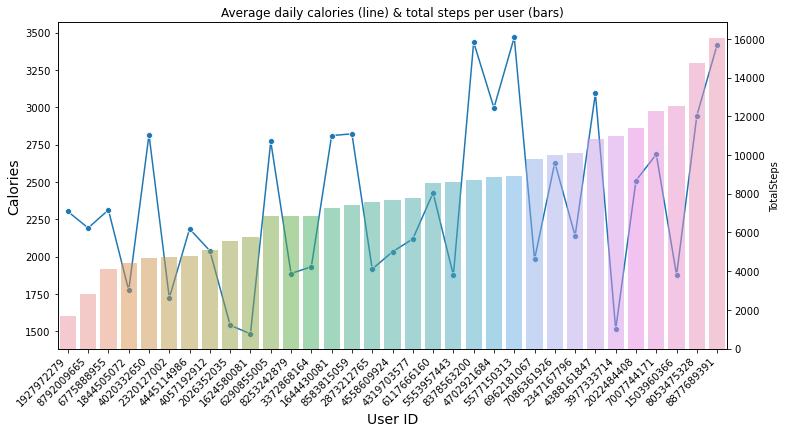

```python
#group the dataset by ID and then apply mean() function to get the average per user,
#reset the index so all column names have the same hierarchy
g = activity.groupby(['Id']).mean().reset_index()
h = g[['TotalSteps','Calories','Id']].sort_values(['TotalSteps']).reset_index().drop(['index'],axis=1)
order_Id = h['Id'].to_list()
fig, ax1 = plt.subplots(figsize=(12,6))

#change the orientation of the x-axis to 45 degrees due to length of user ID
plt.xticks(rotation=45, horizontalalignment='right')
sns.lineplot(data = h['Calories'], marker='o', ax=ax1, sort=False)
plt.xlabel('User ID', size=14)
plt.ylabel('Calories', size=14)
ax2 = ax1.twinx()
sns.barplot(data = h, x='Id', y='TotalSteps', alpha=0.5, ax=ax2, order=order_Id)
plt.title('Average daily calories (line) & total steps per user (bars)')
plt.rcParams['figure.dpi'] = 200;
```

Daily average steps as well as daily average calories vary a lot for the population. In addition we can see that people with similar daily steps show different calorie levels. This might be due to different levels of intensities or non-step based activities such as cycling or swimming. Running for half an hour consumes significantly more calories than walking for the same amount of time. Therefore let's have a closer look at the breakdown of activity intensities (lightly active, fairly active, very active) per user in average.

```python
activity['Day'].value_counts().mean()
```

```
121.85714285714286
```

```python
activity.DayName.value_counts()
```

```
Tuesday      137
Wednesday    137
Thursday     132
Friday       118
Saturday     112
Monday       109
Sunday       108
Name: DayName, dtype: int64
```

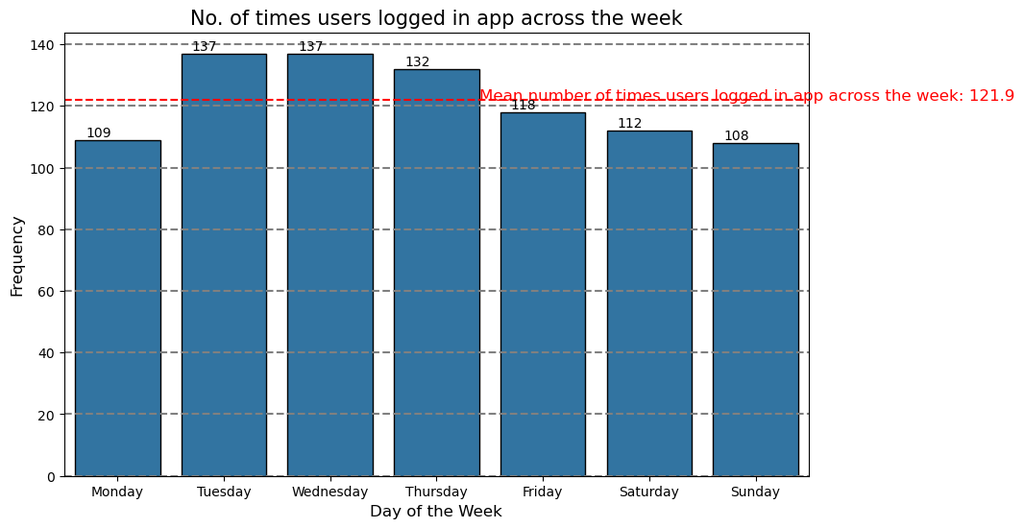

```python
plt.style.use("default")

plt.figure(figsize=[10,6])
base_color=sns.color_palette()[0]
ax=sns.countplot(data=activity,
                 x=activity['DayName'],
                 color = base_color,
                 edgecolor = "black",
                 order=["Monday", "Tuesday", "Wednesday", "Thursday", "Friday", "Saturday", "Sunday"])

plt.axhline(y = activity["DayName"].value_counts().mean(),
            color = 'r',
            linestyle = '--')

plt.text(3.4, 121.85,
         'Mean number of times users logged in app across the week: {:.1f}'.format(activity["DayName"].value_counts().mean()),
         size=12,
         color="red")

for p in ax.patches:
        plt.annotate('{:.0f}'.format(p.get_height()), (p.get_x()+0.1, p.get_height()+1))

# Add title
plt.title("No. of times users logged in app across the week", fontsize=15)


# Add y label
plt.ylabel("Frequency", fontsize=12)

# Add x label
plt.xlabel("Day of the Week", fontsize=12)

plt.grid(axis="y",color = 'grey', linestyle = '--', linewidth = 1.5)
# plt.grid(True)
plt.show()
```

- **Frequency of usage across the week**

In this histogram, we are looking at the frequency of FitBit app usage in terms of days of the week.

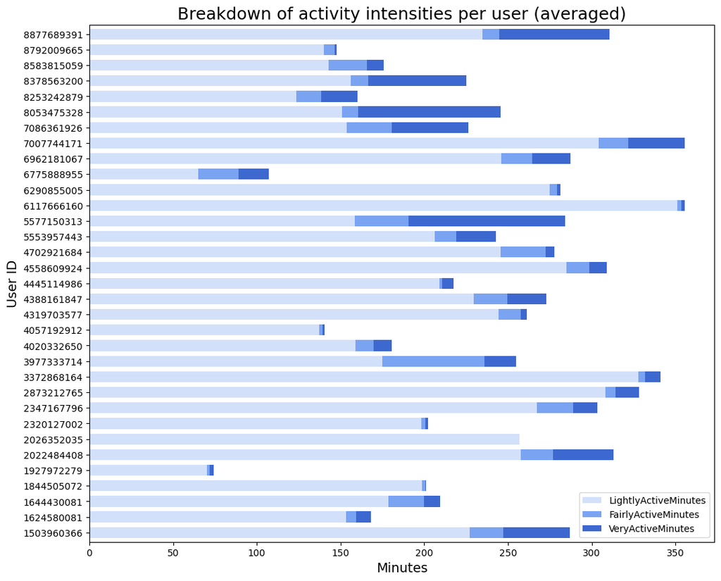

```python
# stacked barcharts with more than 2 values are tricky in seaborn. Therefore I use matplotlib

g = activity.groupby(['Id']).mean().reset_index()
df = g[['Id','LightlyActiveMinutes','FairlyActiveMinutes','VeryActiveMinutes']]

fig, ax = plt.subplots(figsize=(12, 10))

#I prefer a horizontal bar orientation since it is easier to compare
df.plot(
    x = 'Id',
    kind = 'barh',
    stacked = True,
    mark_right = True,
    color=['#D3E0F9','#7AA3F1','#3D68CF'],
    width=0.7,
    ax=ax)

plt.xlabel('Minutes', size=14)
plt.ylabel('User ID', size=14)
plt.title('Breakdown of activity intensities per user (averaged)', size=18)
plt.legend(loc='lower right');
```

The intensities also strongly vary among the population. Some users have almost no very active minutes which means that they almost never perform sports or activities bigger than 6 METs, such as jogging, swimming, cycling (faster speeds), weight-lifting.

```python
g[g['VeryActiveMinutes']>30]
```

|  | Id | Day | Month | Year | TotalSteps | TrackerDistance | LoggedActivitiesDistance | VeryActiveDistance | ModeratelyActiveDistance | LightActiveDistance | SedentaryActiveDistance | VeryActiveMinutes | FairlyActiveMinutes | LightlyActiveMinutes | SedentaryMinutes | Calories | TotalMinutes | TotalHours |
| --- | --- | --- | --- | --- | --- | --- | --- | --- | --- | --- | --- | --- | --- | --- | --- | --- | --- | --- |
| 0 | 1503960366 | 2.900000 | 2.900000 | 2016.0 | 12520.633333 | 8.070000 | 0.000000 | 2.953667 | 0.820667 | 4.291333 | 0.0 | 40.000000 | 19.800000 | 227.266667 | 828.433333 | 1876.966667 | 1115.500000 | 18.600000 |
| 5 | 2022484408 | 2.903226 | 2.903226 | 2016.0 | 11370.645161 | 8.084193 | 0.000000 | 2.421613 | 0.720000 | 4.942581 | 0.0 | 36.290323 | 19.354839 | 257.451613 | 1112.580645 | 2509.967742 | 1425.677419 | 23.774194 |
| 20 | 5577150313 | 2.714286 | 2.714286 | 2016.0 | 8897.607143 | 6.657143 | 0.000000 | 3.336071 | 0.705000 | 2.601429 | 0.0 | 93.571429 | 31.964286 | 158.500000 | 705.464286 | 3469.678571 | 989.500000 | 16.392857 |
| 25 | 7007744171 | 2.958333 | 2.958333 | 2016.0 | 12267.041667 | 8.207083 | 2.295229 | 2.616250 | 0.800000 | 5.266667 | 0.0 | 33.625000 | 17.625000 | 304.125000 | 1078.666667 | 2686.125000 | 1434.041667 | 23.916667 |
| 26 | 7086361926 | 2.724138 | 2.724138 | 2016.0 | 10017.034483 | 6.828276 | 0.000000 | 2.973103 | 0.826552 | 3.012759 | 0.0 | 45.517241 | 27.103448 | 153.655172 | 809.896552 | 2630.793103 | 1036.172414 | 17.241379 |
| 27 | 8053475328 | 2.903226 | 2.903226 | 2016.0 | 14763.290323 | 11.475161 | 0.000000 | 8.514839 | 0.423871 | 2.533871 | 0.0 | 85.161290 | 9.580645 | 150.967742 | 1148.000000 | 2945.806452 | 1393.709677 | 23.225806 |
| 29 | 8378563200 | 2.903226 | 2.903226 | 2016.0 | 8717.709677 | 6.913548 | 1.116158 | 2.503548 | 0.519032 | 3.889355 | 0.0 | 58.677419 | 10.258065 | 156.096774 | 716.129032 | 3436.580645 | 941.161290 | 15.709677 |
| 32 | 8877689391 | 2.903226 | 2.903226 | 2016.0 | 16040.032258 | 13.212903 | 0.000000 | 6.637419 | 0.337742 | 6.188710 | 0.0 | 66.064516 | 9.935484 | 234.709677 | 1112.870968 | 3420.258065 | 1423.580645 | 23.741935 |

8 users have more than 30 very active minutes daily in average.

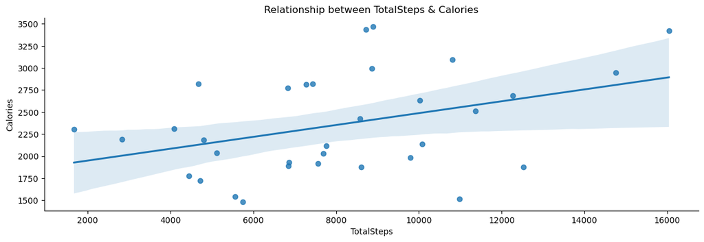

```python
sns.lmplot(x='TotalSteps',y='Calories',data=g,height=4,aspect=3)
plt.title('Relationship between TotalSteps & Calories');
```

There is no very clear positive correlation between total steps and calories. The regression line which minimizes the distance to all points to the line doesn't support a strong correlation. Only a few datapoints would be needed to change the slope from positive to negative. Let's check the exact correlation of all relevant features via a heatmap.

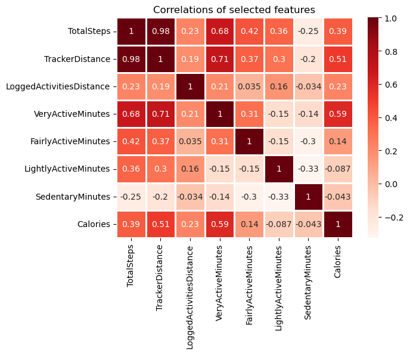

```python
sns.heatmap(g[['TotalSteps','TrackerDistance','LoggedActivitiesDistance',
               'VeryActiveMinutes','FairlyActiveMinutes','LightlyActiveMinutes','SedentaryMinutes',
               'Calories']].corr(),cmap='Reds',linecolor='white',linewidths=1,annot=True)
plt.title('Correlations of selected features');
```

**Therefore let's only assign those correlations a preliminary validity which is to be proven by a larger dataset.**

```python
activity['LoggedActivitiesDistance'].value_counts()
```

```
0.000000    821
2.092147      9
2.253081      7
4.081692      1
4.861792      1
4.878232      1
4.912368      1
2.832326      1
4.911146      1
4.885605      1
4.924841      1
2.785175      1
1.959596      1
4.930550      1
3.285415      1
4.851307      1
4.869783      1
3.167822      1
4.942142      1
Name: LoggedActivitiesDistance, dtype: int64
```

Users only logged their activities for 32 times out of 853 (verified) times. 821 times activity hasn't been logged.

- **Let's verify the hypothesis if people are more active at the weekend by checking calories and daily steps based on week days.**

```python
activity.groupby(['Day']).mean().reset_index().drop(['Id'],axis=1)
```

|  | Day | Month | Year | TotalSteps | TrackerDistance | LoggedActivitiesDistance | VeryActiveDistance | ModeratelyActiveDistance | LightActiveDistance | SedentaryActiveDistance | VeryActiveMinutes | FairlyActiveMinutes | LightlyActiveMinutes | SedentaryMinutes | Calories | TotalMinutes | TotalHours |
| --- | --- | --- | --- | --- | --- | --- | --- | --- | --- | --- | --- | --- | --- | --- | --- | --- | --- |
| 0 | 0 | 0.0 | 2016.0 | 8565.522936 | 6.086330 | 0.247213 | 1.692477 | 0.644954 | 3.702110 | 0.0 | 25.440367 | 15.412844 | 211.422018 | 986.376147 | 2389.201835 | 1238.651376 | 20.669725 |
| 1 | 1 | 1.0 | 2016.0 | 9014.540146 | 6.449197 | 0.187564 | 1.789927 | 0.657956 | 3.851022 | 0.0 | 25.467153 | 15.905109 | 218.941606 | 970.160584 | 2445.343066 | 1230.474453 | 20.467153 |
| 2 | 2 | 2.0 | 2016.0 | 8276.598540 | 5.986350 | 0.152834 | 1.788467 | 0.577080 | 3.565255 | 0.0 | 22.751825 | 14.343066 | 207.854015 | 946.744526 | 2353.897810 | 1191.693431 | 19.846715 |
| 3 | 3 | 3.0 | 2016.0 | 8247.280303 | 5.888182 | 0.143974 | 1.548485 | 0.562576 | 3.656136 | 0.0 | 21.613636 | 13.318182 | 206.477273 | 927.696970 | 2289.719697 | 1169.106061 | 19.500000 |
| 4 | 4 | 4.0 | 2016.0 | 7952.466102 | 5.661949 | 0.077080 | 1.401949 | 0.516610 | 3.725169 | 0.0 | 21.415254 | 12.932203 | 217.991525 | 982.703390 | 2376.601695 | 1235.042373 | 20.593220 |
| 5 | 5 | 5.0 | 2016.0 | 9026.232143 | 6.481875 | 0.000000 | 1.676875 | 0.749911 | 4.004643 | 0.0 | 23.973214 | 16.830357 | 229.312500 | 925.500000 | 2435.839286 | 1195.616071 | 19.955357 |
| 6 | 6 | 6.0 | 2016.0 | 7767.370370 | 5.632037 | 0.000000 | 1.668148 | 0.692407 | 3.240185 | 0.0 | 22.388889 | 16.277778 | 194.870370 | 936.851852 | 2321.740741 | 1170.388889 | 19.500000 |

```python
activity.groupby(['DayName']).mean().reset_index().drop(['Id'],axis=1)
```

|  | DayName | Day | Month | Year | TotalSteps | TrackerDistance | LoggedActivitiesDistance | VeryActiveDistance | ModeratelyActiveDistance | LightActiveDistance | SedentaryActiveDistance | VeryActiveMinutes | FairlyActiveMinutes | LightlyActiveMinutes | SedentaryMinutes | Calories | TotalMinutes | TotalHours |
| --- | --- | --- | --- | --- | --- | --- | --- | --- | --- | --- | --- | --- | --- | --- | --- | --- | --- | --- |
| 0 | Friday | 4.0 | 4.0 | 2016.0 | 7952.466102 | 5.661949 | 0.077080 | 1.401949 | 0.516610 | 3.725169 | 0.0 | 21.415254 | 12.932203 | 217.991525 | 982.703390 | 2376.601695 | 1235.042373 | 20.593220 |
| 1 | Monday | 0.0 | 0.0 | 2016.0 | 8565.522936 | 6.086330 | 0.247213 | 1.692477 | 0.644954 | 3.702110 | 0.0 | 25.440367 | 15.412844 | 211.422018 | 986.376147 | 2389.201835 | 1238.651376 | 20.669725 |
| 2 | Saturday | 5.0 | 5.0 | 2016.0 | 9026.232143 | 6.481875 | 0.000000 | 1.676875 | 0.749911 | 4.004643 | 0.0 | 23.973214 | 16.830357 | 229.312500 | 925.500000 | 2435.839286 | 1195.616071 | 19.955357 |
| 3 | Sunday | 6.0 | 6.0 | 2016.0 | 7767.370370 | 5.632037 | 0.000000 | 1.668148 | 0.692407 | 3.240185 | 0.0 | 22.388889 | 16.277778 | 194.870370 | 936.851852 | 2321.740741 | 1170.388889 | 19.500000 |
| 4 | Thursday | 3.0 | 3.0 | 2016.0 | 8247.280303 | 5.888182 | 0.143974 | 1.548485 | 0.562576 | 3.656136 | 0.0 | 21.613636 | 13.318182 | 206.477273 | 927.696970 | 2289.719697 | 1169.106061 | 19.500000 |
| 5 | Tuesday | 1.0 | 1.0 | 2016.0 | 9014.540146 | 6.449197 | 0.187564 | 1.789927 | 0.657956 | 3.851022 | 0.0 | 25.467153 | 15.905109 | 218.941606 | 970.160584 | 2445.343066 | 1230.474453 | 20.467153 |
| 6 | Wednesday | 2.0 | 2.0 | 2016.0 | 8276.598540 | 5.986350 | 0.152834 | 1.788467 | 0.577080 | 3.565255 | 0.0 | 22.751825 | 14.343066 | 207.854015 | 946.744526 | 2353.897810 | 1191.693431 | 19.846715 |

**Tuesday** and **Saturday** have the highest average step numbers as well as calorie consumption.

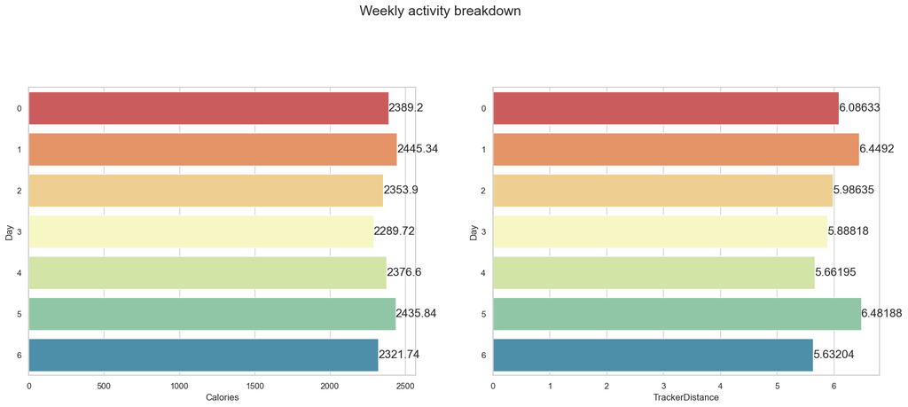

```python
from matplotlib.gridspec import GridSpec
sns.set(style="whitegrid")

w = activity.groupby(['Day']).mean().reset_index()

plt.figure(2, figsize=(20,15))
the_grid = GridSpec(2, 2)

plt.subplot(the_grid[0, 1], title='')


a=sns.barplot(x='TrackerDistance', y='Day', data=w.sort_values(['TrackerDistance']).reset_index(drop=True), palette='Spectral', orient='horizontal')
a.bar_label(a.containers[0], fontsize=15)

plt.subplot(the_grid[0, 0], title='')

b=sns.barplot(x='Calories', y='Day', data=w.sort_values(['Calories']).reset_index(drop=True), palette='Spectral', orient='horizontal')
b.bar_label(b.containers[0], fontsize=15)


plt.suptitle('Weekly activity breakdown', fontsize=18);
```

For completeness, let's also look into the time when people are most active. I want to approach this problem via couting the calories burned per hour aggregated for the whole population.

## -

> - ### Hourly calories dataset

```python
HourlyCalories.head(5)
```

|  | Id | ActivityHour | Calories |
| --- | --- | --- | --- |
| 0 | 1503960366 | 4/12/2016 12:00:00 AM | 81 |
| 1 | 1503960366 | 4/12/2016 1:00:00 AM | 61 |
| 2 | 1503960366 | 4/12/2016 2:00:00 AM | 59 |
| 3 | 1503960366 | 4/12/2016 3:00:00 AM | 47 |
| 4 | 1503960366 | 4/12/2016 4:00:00 AM | 48 |

```python
HourlyCalories.info()
```

```
<class 'pandas.core.frame.DataFrame'>
RangeIndex: 22099 entries, 0 to 22098
Data columns (total 3 columns):
 #   Column        Non-Null Count  Dtype
---  ------        --------------  -----
 0   Id            22099 non-null  int64
 1   ActivityHour  22099 non-null  object
 2   Calories      22099 non-null  int64
dtypes: int64(2), object(1)
memory usage: 518.1+ KB
```

There are no null values. Let's convert the column activity hour into a Python date time object.

```python
HourlyCalories.duplicated().sum()
```

```
0
```

- **Check how many users have provided at least one data point**

```python
HourlyCalories['Id'].nunique()
```

```
33
```

- **Convert to pandas date time object**

```python
HourlyCalories['ActivityHour_new']= pd.to_datetime(HourlyCalories['ActivityHour'])
HourlyCalories.drop(labels=['ActivityHour'], axis=1, inplace = True)
HourlyCalories.head(3)
```

|  | Id | Calories | ActivityHour_new |
| --- | --- | --- | --- |
| 0 | 1503960366 | 81 | 2016-04-12 00:00:00 |
| 1 | 1503960366 | 61 | 2016-04-12 01:00:00 |
| 2 | 1503960366 | 59 | 2016-04-12 02:00:00 |

- **Let's create a new column which assigns the day of the week and then plot two diagrams: average calories per hour during weekdays and during the weekend.**

```python
#extract week day from column ActivityHour_new and create a new column for that
#Monday = 0, Tuesday = 1, ... Saturday = 5, Sunday = 6
HourlyCalories['Day'] = pd.to_datetime(HourlyCalories['ActivityHour_new']).dt.dayofweek

#weekend
HourlyCaloriesWeekend = HourlyCalories[HourlyCalories['Day']>=5]

#week day
HourlyCaloriesWeekdays = HourlyCalories[HourlyCalories['Day']<5]
```

- **Let's Visualize this**

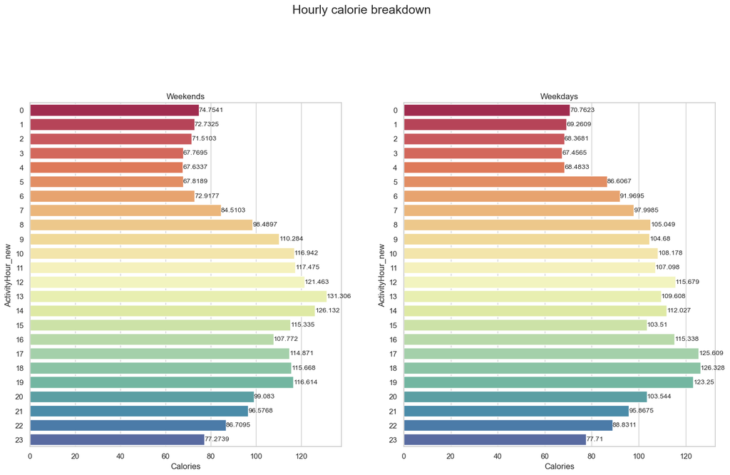

```python
from matplotlib.gridspec import GridSpec
sns.set(style="whitegrid")

#data
Weekday = HourlyCaloriesWeekdays.groupby(HourlyCaloriesWeekdays["ActivityHour_new"].dt.hour).mean().reset_index()
Weekend = HourlyCaloriesWeekend.groupby(HourlyCaloriesWeekend["ActivityHour_new"].dt.hour).mean().reset_index()

plt.figure(2, figsize=(18,20))
the_grid = GridSpec(2, 2)

# first plot weekdays
plt.subplot(the_grid[0, 1], title='Weekdays')
a=sns.barplot(x='Calories', y='ActivityHour_new', data=Weekday, palette='Spectral', orient='horizontal')
a.bar_label(a.containers[0], fontsize=10)

# second plot weekend
plt.subplot(the_grid[0, 0], title='Weekends')
b=sns.barplot(x='Calories', y='ActivityHour_new', data=Weekend, palette='Spectral', orient='horizontal')
b.bar_label(b.containers[0], fontsize=10)

# overall title
plt.suptitle('Hourly calorie breakdown', fontsize=18);
```

On *weekends*, people are most active from *12-3pm*. During the week*(weekdays)* from *5-8pm* (which is probably for most people after work).

### Weight data

- **Now let's have a look at the second csv file, the ***WeightInfo* file.

```python
WeightInfo.sample(2)
```

|  | Id | Date | WeightKg | WeightPounds | Fat | BMI | IsManualReport | LogId |
| --- | --- | --- | --- | --- | --- | --- | --- | --- |
| 7 | 4558609924 | 4/18/2016 11:59:59 PM | 69.699997 | 153.662190 | NaN | 27.250000 | True | 1461023999000 |
| 13 | 6962181067 | 4/12/2016 11:59:59 PM | 62.500000 | 137.788914 | NaN | 24.389999 | True | 1460505599000 |

```python
WeightInfo.info()
```

```
<class 'pandas.core.frame.DataFrame'>
RangeIndex: 67 entries, 0 to 66
Data columns (total 8 columns):
 #   Column          Non-Null Count  Dtype
---  ------          --------------  -----
 0   Id              67 non-null     int64
 1   Date            67 non-null     object
 2   WeightKg        67 non-null     float64
 3   WeightPounds    67 non-null     float64
 4   Fat             2 non-null      float64
 5   BMI             67 non-null     float64
 6   IsManualReport  67 non-null     bool
 7   LogId           67 non-null     int64
dtypes: bool(1), float64(4), int64(2), object(1)
memory usage: 3.9+ KB
```

```python
WeightInfo.duplicated().sum()
```

```
0
```

```python
WeightInfo.isnull().sum()
```

```
Id                 0
Date               0
WeightKg           0
WeightPounds       0
Fat               65
BMI                0
IsManualReport     0
LogId              0
dtype: int64
```

```python
WeightInfo.describe()
```

|  | Id | WeightKg | WeightPounds | Fat | BMI | LogId |
| --- | --- | --- | --- | --- | --- | --- |
| count | 6.700000e+01 | 67.000000 | 67.000000 | 2.00000 | 67.000000 | 6.700000e+01 |
| mean | 7.009282e+09 | 72.035821 | 158.811801 | 23.50000 | 25.185224 | 1.461772e+12 |
| std | 1.950322e+09 | 13.923206 | 30.695415 | 2.12132 | 3.066963 | 7.829948e+08 |
| min | 1.503960e+09 | 52.599998 | 115.963147 | 22.00000 | 21.450001 | 1.460444e+12 |
| 25% | 6.962181e+09 | 61.400002 | 135.363832 | 22.75000 | 23.959999 | 1.461079e+12 |
| 50% | 6.962181e+09 | 62.500000 | 137.788914 | 23.50000 | 24.389999 | 1.461802e+12 |
| 75% | 8.877689e+09 | 85.049999 | 187.503152 | 24.25000 | 25.559999 | 1.462375e+12 |
| max | 8.877689e+09 | 133.500000 | 294.317120 | 25.00000 | 47.540001 | 1.463098e+12 |

- The *date* is again in string format. Let's convert it into a Pandas date type object.
- There are only 67 *entries* out of originally 940 entries, which could show again that only few users adjust settings or provide additional input over time if all devices would support this feature. Let's check how many unique users have edited their weight.
- The body *fat* percentage column ('Fat') shows 65 rows of missing data (NaN), only 2 valid data points are available. Let's delete that column
- Checking the meaning of IsManualReport on the FitBit website (https://www.fitabase.com/media/1748/fitabasedatadictionary.pdf), shows that the value True means that there was a manual input and False that the value was automatically received from a connected scale. Obviously the participants of the survey own more than one Fitbit product or were equipped with it as part of the study. Let's count the values later.
- The *logId* is the unique logID into the FitBit system. Due to privacy concerns, it shouldn't have been listed here unless it has been anonymized. Let's delete this column.
- Maximum *BMI* is 47.5, which is almost morbid obesity. Let's check if this outlier fits the other data we have for this user.

```python
WeightInfo['Id'].unique()
```

```
array([1503960366, 1927972279, 2873212765, 4319703577, 4558609924,
       5577150313, 6962181067, 8877689391], dtype=int64)
```

Only 8 out of 33 users have provided any weight related data.

- **delete the columns LogId and Fat**

```python
WeightInfo.drop('LogId', inplace=True, axis=1)
WeightInfo.drop('Fat', inplace=True, axis=1)
```

- **Create a new column 'date_new' based on 'Date'**

```python
#create a new column 'date_new' based on 'Date'
WeightInfo['date_new'] = WeightInfo['Date']
```

- **Convert the object data type into a Pandas date time object**

```python
WeightInfo['date_new']= pd.to_datetime(WeightInfo['date_new'])
WeightInfo.drop(labels=['Date'], axis=1, inplace = True)
WeightInfo.sample(3)
```

|  | Id | WeightKg | WeightPounds | BMI | IsManualReport | date_new |
| --- | --- | --- | --- | --- | --- | --- |
| 32 | 6962181067 | 61.5 | 135.584291 | 24.00 | True | 2016-05-02 23:59:59 |
| 36 | 6962181067 | 61.5 | 135.584291 | 24.00 | True | 2016-05-06 23:59:59 |
| 58 | 8877689391 | 85.5 | 188.495234 | 25.59 | False | 2016-04-30 07:49:03 |

```python
WeightInfoGrouped = WeightInfo.groupby(['Id']).mean()
WeightInfoGrouped['IsManualReport'].value_counts()
```

```
1.0    5
0.0    3
Name: IsManualReport, dtype: int64
```

*3 of 8* users who logged their weight have a scale that is connected to their FitBit account. Having a scale which is automatically connected is a huge improvement in terms of user experience. The user doesn't need to record the weight manually.

- **Let's rearrange the dataframe by ID to see the average BMI**

```python
WeightInfo.groupby(['Id']).mean().reset_index()
```

|  | Id | WeightKg | WeightPounds | BMI | IsManualReport |
| --- | --- | --- | --- | --- | --- |
| 0 | 1503960366 | 52.599998 | 115.963147 | 22.650000 | 1.0 |
| 1 | 1927972279 | 133.500000 | 294.317120 | 47.540001 | 0.0 |
| 2 | 2873212765 | 57.000000 | 125.663489 | 21.570001 | 1.0 |
| 3 | 4319703577 | 72.350002 | 159.504452 | 27.415000 | 1.0 |
| 4 | 4558609924 | 69.639999 | 153.529918 | 27.214000 | 1.0 |
| 5 | 5577150313 | 90.699997 | 199.959265 | 28.000000 | 0.0 |
| 6 | 6962181067 | 61.553334 | 135.701872 | 24.028000 | 1.0 |
| 7 | 8877689391 | 85.145834 | 187.714432 | 25.487083 | 0.0 |

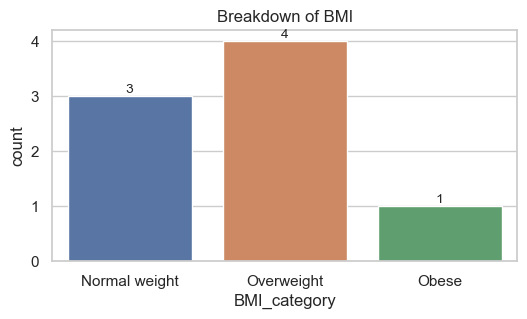

```python
def BMI_category(x):

    if x>18.5 and x<25:
        return "Normal weight"
    elif x>=25 and x<30:
        return "Overweight"
    elif x>=30:
        return "Obese"

data = WeightInfo.groupby(['Id']).mean().reset_index()

#use lambda function to create a new column based on ranges
data['BMI_category'] = data['BMI'].apply(lambda x: BMI_category(x))
data

fig, ax1 = plt.subplots(figsize=(6,3))
a=sns.countplot(x='BMI_category', data=data, order=['Normal weight', 'Overweight', 'Obese']);
a.bar_label(a.containers[0], fontsize=10)

plt.title('Breakdown of BMI');
```

- **Let's compare the first recorded weight with the last one to see if there is any weight loss/gain.**

```python
#create list of unique IDs
WeightID = WeightInfo['Id'].unique()

#for loop to append earliest_date, latest_date and weight_dif list
EarliestDate = []
LatestDate = []
WeightDifference = []
for x in WeightID:
    #use min() and max() function to find earliest/latest recording
    #alternative: use sort_values function
    a = WeightInfo[WeightInfo['Id']==x]
    EarliestDate.append(a['date_new'].min())
    LatestDate.append(a['date_new'].max())
    #sort values by date in order to pick first and last weight
    b = a.sort_values('date_new')
    #calculate difference between earliest recorded and last recorded weight
    dif = b['WeightKg'].tolist()[-1]-b['WeightKg'].tolist()[0]
    WeightDifference.append(dif)

#check the number of weight records for each user
NumberOfRecords = []
for x in WeightID:
    IndividualRecords = WeightInfo[WeightInfo['Id']==x]['Id'].tolist()
    c = len(IndividualRecords)
    NumberOfRecords.append(c)

#convert lists into dataframe
a_dict = {"Id":WeightID,
          "Earliest Date":EarliestDate,
          "Latest Date":LatestDate,
          "Weight Difference": WeightDifference,
          "Number of Records":NumberOfRecords}
NewData = pd.DataFrame(a_dict)
difference = NewData['Latest Date']-NewData['Earliest Date']
NewData.insert(3,'Time Difference', difference, True)
NewData
```

|  | Id | Earliest Date | Latest Date | Time Difference | Weight Difference | Number of Records |
| --- | --- | --- | --- | --- | --- | --- |
| 0 | 1503960366 | 2016-05-02 23:59:59 | 2016-05-03 23:59:59 | 1 days 00:00:00 | 0.000000 | 2 |
| 1 | 1927972279 | 2016-04-13 01:08:52 | 2016-04-13 01:08:52 | 0 days 00:00:00 | 0.000000 | 1 |
| 2 | 2873212765 | 2016-04-21 23:59:59 | 2016-05-12 23:59:59 | 21 days 00:00:00 | 0.599998 | 2 |
| 3 | 4319703577 | 2016-04-17 23:59:59 | 2016-05-04 23:59:59 | 17 days 00:00:00 | -0.099998 | 2 |
| 4 | 4558609924 | 2016-04-18 23:59:59 | 2016-05-09 23:59:59 | 21 days 00:00:00 | -0.599998 | 5 |
| 5 | 5577150313 | 2016-04-17 09:17:55 | 2016-04-17 09:17:55 | 0 days 00:00:00 | 0.000000 | 1 |
| 6 | 6962181067 | 2016-04-12 23:59:59 | 2016-05-12 23:59:59 | 30 days 00:00:00 | -0.599998 | 30 |
| 7 | 8877689391 | 2016-04-12 06:47:11 | 2016-05-12 06:42:53 | 29 days 23:55:42 | -1.800003 | 24 |

- Weight data of only 8 users out of 33 is available (due to unknown reasons such as not supported by device, unwillingness of user, etc.)
- For *2 out of these 8* users there is only one record available, therefore no weight difference can be measured
- In order to measure any weight loss or gain, short periods less than 7 days don't make sense. Only 5 users have provided weight records extending over a period of >7 days (difference between the earliest and latest weight record)
- Furthermore the latest weight record is mostly (much) before the end of the observation period, therefore we don't know the user behavior after that (weight loss could follow weight gain)
- Conclusion: Statistically the number of users is too small, to be representative for a larger population and the quality of the data is not sufficient to draw any conclusions in terms of weight loss/gain. Therefore correlations with other features will be calculated only for the sake of practicing data analysis. Results will not be considered in the summary. The only interesting observation is that 3 of 8 users own a scale that is connected to their FitBit account. Having a scale which is automatically connected would be a huge improvement in terms of user experience. The user doesn't need to record the weight manually and only step onto the scale while the phone is closeby. This hypothesis could be checked by interviewing some those users.
- **Let's check further fitness data for the user 1927972279 with BMI of 47.5**

```python
WeightInfo[WeightInfo['Id']==1927972279]['WeightKg']
```

```
2    133.5
Name: WeightKg, dtype: float64
```

```python
activity[activity['Id']==1927972279]
```

|  | Id | ActivityDate | Day | DayName | Month | MonthName | Year | TotalSteps | TrackerDistance | LoggedActivitiesDistance | ... | ModeratelyActiveDistance | LightActiveDistance | SedentaryActiveDistance | VeryActiveMinutes | FairlyActiveMinutes | LightlyActiveMinutes | SedentaryMinutes | Calories | TotalMinutes | TotalHours |
| --- | --- | --- | --- | --- | --- | --- | --- | --- | --- | --- | --- | --- | --- | --- | --- | --- | --- | --- | --- | --- | --- |
| 123 | 1927972279 | 2016-04-12 | 1 | Tuesday | 1 | Apr | 2016 | 678 | 0.47 | 0.0 | ... | 0.00 | 0.47 | 0 | 0 | 0 | 55 | 734 | 2220 | 789 | 13.0 |
| 124 | 1927972279 | 2016-04-13 | 2 | Wednesday | 2 | Apr | 2016 | 356 | 0.25 | 0.0 | ... | 0.00 | 0.25 | 0 | 0 | 0 | 32 | 986 | 2151 | 1018 | 17.0 |
| 125 | 1927972279 | 2016-04-14 | 3 | Thursday | 3 | Apr | 2016 | 2163 | 1.50 | 0.0 | ... | 0.40 | 1.10 | 0 | 0 | 9 | 88 | 1292 | 2383 | 1389 | 23.0 |
| 126 | 1927972279 | 2016-04-15 | 4 | Friday | 4 | Apr | 2016 | 980 | 0.68 | 0.0 | ... | 0.00 | 0.68 | 0 | 0 | 0 | 51 | 941 | 2221 | 992 | 17.0 |
| 129 | 1927972279 | 2016-04-18 | 0 | Monday | 0 | Apr | 2016 | 244 | 0.17 | 0.0 | ... | 0.00 | 0.17 | 0 | 0 | 0 | 17 | 1423 | 2111 | 1440 | 24.0 |
| 133 | 1927972279 | 2016-04-22 | 4 | Friday | 4 | Apr | 2016 | 149 | 0.10 | 0.0 | ... | 0.00 | 0.10 | 0 | 0 | 0 | 10 | 1430 | 2093 | 1440 | 24.0 |
| 134 | 1927972279 | 2016-04-23 | 5 | Saturday | 5 | Apr | 2016 | 2945 | 2.04 | 0.0 | ... | 0.00 | 2.04 | 0 | 0 | 0 | 145 | 1295 | 2499 | 1440 | 24.0 |
| 135 | 1927972279 | 2016-04-24 | 6 | Sunday | 6 | Apr | 2016 | 2090 | 1.45 | 0.0 | ... | 0.24 | 1.14 | 0 | 1 | 6 | 75 | 1358 | 2324 | 1440 | 24.0 |
| 136 | 1927972279 | 2016-04-25 | 0 | Monday | 0 | Apr | 2016 | 152 | 0.11 | 0.0 | ... | 0.00 | 0.11 | 0 | 0 | 0 | 12 | 1303 | 2100 | 1315 | 22.0 |
| 137 | 1927972279 | 2016-04-26 | 1 | Tuesday | 1 | Apr | 2016 | 3761 | 2.60 | 0.0 | ... | 0.00 | 2.60 | 0 | 0 | 0 | 192 | 1058 | 2638 | 1250 | 21.0 |
| 139 | 1927972279 | 2016-04-28 | 3 | Thursday | 3 | Apr | 2016 | 1675 | 1.16 | 0.0 | ... | 0.00 | 1.16 | 0 | 0 | 0 | 95 | 1167 | 2351 | 1262 | 21.0 |
| 142 | 1927972279 | 2016-05-01 | 6 | Sunday | 6 | May | 2016 | 2704 | 1.87 | 0.0 | ... | 0.03 | 0.83 | 0 | 14 | 1 | 70 | 1355 | 2411 | 1440 | 24.0 |
| 143 | 1927972279 | 2016-05-02 | 0 | Monday | 0 | May | 2016 | 3790 | 2.62 | 0.0 | ... | 0.30 | 1.16 | 0 | 16 | 8 | 94 | 1322 | 2505 | 1440 | 24.0 |
| 144 | 1927972279 | 2016-05-03 | 1 | Tuesday | 1 | May | 2016 | 1326 | 0.92 | 0.0 | ... | 0.00 | 0.18 | 0 | 10 | 0 | 17 | 1413 | 2195 | 1440 | 24.0 |
| 145 | 1927972279 | 2016-05-04 | 2 | Wednesday | 2 | May | 2016 | 1786 | 1.24 | 0.0 | ... | 0.00 | 1.24 | 0 | 0 | 0 | 87 | 1353 | 2338 | 1440 | 24.0 |
| 147 | 1927972279 | 2016-05-06 | 4 | Friday | 4 | May | 2016 | 2091 | 1.45 | 0.0 | ... | 0.00 | 1.45 | 0 | 0 | 0 | 108 | 1332 | 2383 | 1440 | 24.0 |
| 148 | 1927972279 | 2016-05-07 | 5 | Saturday | 5 | May | 2016 | 1510 | 1.04 | 0.0 | ... | 0.00 | 1.04 | 0 | 0 | 0 | 48 | 1392 | 2229 | 1440 | 24.0 |

17 rows × 21 columns

Daily steps show that this user doesn't move a lot which is probably related to the high body weight of 133kg (at a low body height if you calculate the height based on the BMI formula backwards). For this specific user the entries where TotalSteps equal 0 which we deleted before might make sense. Let's revisit that data and compare this to the weight information we have.

- **Reload the `activity csv` file since some rows were deleted before**

```python
activity_raw=pd.read_csv("C:/Users/kariu/OneDrive/Desktop/Data Science/Google_Capstone_Project/FitBit Fitness Tracker Data/Fitabase Data/dailyActivity_merged.csv")
activity_raw[['Id','TotalSteps','SedentaryMinutes','Calories']].groupby(['Id']).mean()
```

| Id | TotalSteps | SedentaryMinutes | Calories |
| --- | --- | --- | --- |
| 1503960366 | 12116.741935 | 848.161290 | 1816.419355 |
| 1624580081 | 5743.903226 | 1257.741935 | 1483.354839 |
| 1644430081 | 7282.966667 | 1161.866667 | 2811.300000 |
| 1844505072 | 2580.064516 | 1206.612903 | 1573.483871 |
| 1927972279 | 916.129032 | 1317.419355 | 2172.806452 |
| 2022484408 | 11370.645161 | 1112.580645 | 2509.967742 |
| 2026352035 | 5566.870968 | 689.419355 | 1540.645161 |
| 2320127002 | 4716.870968 | 1220.096774 | 1724.161290 |
| 2347167796 | 9519.666667 | 687.166667 | 2043.444444 |
| 2873212765 | 7555.774194 | 1097.193548 | 1916.967742 |
| 3372868164 | 6861.650000 | 1077.550000 | 1933.100000 |
| 3977333714 | 10984.566667 | 707.533333 | 1513.666667 |
| 4020332650 | 2267.225806 | 1237.258065 | 2385.806452 |
| 4057192912 | 3838.000000 | 1217.250000 | 1973.750000 |
| 4319703577 | 7268.838710 | 735.806452 | 2037.677419 |
| 4388161847 | 10813.935484 | 836.677419 | 3093.870968 |
| 4445114986 | 4796.548387 | 829.903226 | 2186.193548 |
| 4558609924 | 7685.129032 | 1093.612903 | 2033.258065 |
| 4702921684 | 8572.064516 | 766.419355 | 2965.548387 |
| 5553957443 | 8612.580645 | 668.354839 | 1875.677419 |
| 5577150313 | 8304.433333 | 754.433333 | 3359.633333 |
| 6117666160 | 7046.714286 | 796.285714 | 2261.142857 |
| 6290855005 | 5649.551724 | 1193.034483 | 2599.620690 |
| 6775888955 | 2519.692308 | 1299.423077 | 2131.769231 |
| 6962181067 | 9794.806452 | 662.322581 | 1982.032258 |
| 7007744171 | 11323.423077 | 1055.346154 | 2544.000000 |
| 7086361926 | 9371.774194 | 850.451613 | 2566.354839 |
| 8053475328 | 14763.290323 | 1148.000000 | 2945.806452 |
| 8253242879 | 6482.157895 | 1287.368421 | 1788.000000 |
| 8378563200 | 8717.709677 | 716.129032 | 3436.580645 |
| 8583815059 | 7198.516129 | 1267.225806 | 2732.032258 |
| 8792009665 | 1853.724138 | 1060.482759 | 1962.310345 |
| 8877689391 | 16040.032258 | 1112.870968 | 3420.258065 |

Only one user (1927972279) has an average of daily steps < 1000. Therefore let's stick to the previous logic of deleting all values where daily steps are less than 100.

- **As a first step we have to merge two dataframes.**

```python
data1= activity.groupby(['Id']).mean().reset_index()
data2= WeightInfo.groupby(['Id']).mean().reset_index()
data1['BMI'] = data1.merge(data2, on='Id')['BMI']
# delete all rows with NaN
data1 = data1.dropna()
data1[['Id','Calories','BMI']].sort_values('BMI')
```

|  | Id | Calories | BMI |
| --- | --- | --- | --- |
| 2 | 1644430081 | 2811.300000 | 21.570001 |
| 0 | 1503960366 | 1876.966667 | 22.650000 |
| 6 | 2026352035 | 1540.645161 | 24.028000 |
| 7 | 2320127002 | 1724.161290 | 25.487083 |
| 4 | 1927972279 | 2303.058824 | 27.214000 |
| 3 | 1844505072 | 1774.500000 | 27.415000 |
| 5 | 2022484408 | 2509.967742 | 28.000000 |
| 1 | 1624580081 | 1483.354839 | 47.540001 |

```python
data1[['Id','Calories','BMI']].corr()
```

|  | Id | Calories | BMI |
| --- | --- | --- | --- |
| Id | 1.000000 | -0.117448 | -0.205916 |
| Calories | -0.117448 | 1.000000 | -0.440029 |
| BMI | -0.205916 | -0.440029 | 1.000000 |

```python
activity.columns
```

```
Index(['Id', 'ActivityDate', 'Day', 'DayName', 'Month', 'MonthName', 'Year',
       'TotalSteps', 'TrackerDistance', 'LoggedActivitiesDistance',
       'VeryActiveDistance', 'ModeratelyActiveDistance', 'LightActiveDistance',
       'SedentaryActiveDistance', 'VeryActiveMinutes', 'FairlyActiveMinutes',
       'LightlyActiveMinutes', 'SedentaryMinutes', 'Calories', 'TotalMinutes',
       'TotalHours'],
      dtype='object')
```

```python
activity.sample(2)
```

|  | Id | ActivityDate | Day | DayName | Month | MonthName | Year | TotalSteps | TrackerDistance | LoggedActivitiesDistance | ... | ModeratelyActiveDistance | LightActiveDistance | SedentaryActiveDistance | VeryActiveMinutes | FairlyActiveMinutes | LightlyActiveMinutes | SedentaryMinutes | Calories | TotalMinutes | TotalHours |
| --- | --- | --- | --- | --- | --- | --- | --- | --- | --- | --- | --- | --- | --- | --- | --- | --- | --- | --- | --- | --- | --- |
| 757 | 7086361926 | 2016-05-02 | 0 | Monday | 0 | May | 2016 | 10052 | 6.81 | 0.0 | ... | 0.66 | 2.66 | 0 | 66 | 26 | 139 | 737 | 2754 | 968 | 16.0 |
| 539 | 5553957443 | 2016-04-15 | 4 | Friday | 4 | Apr | 2016 | 16556 | 10.86 | 0.0 | ... | 1.98 | 4.71 | 0 | 58 | 38 | 239 | 689 | 2254 | 1024 | 17.0 |

2 rows × 21 columns

```python
activity.describe()
```

|  | Id | Day | Month | Year | TotalSteps | TrackerDistance | LoggedActivitiesDistance | VeryActiveDistance | ModeratelyActiveDistance | LightActiveDistance | SedentaryActiveDistance | VeryActiveMinutes | FairlyActiveMinutes | LightlyActiveMinutes | SedentaryMinutes | Calories | TotalMinutes | TotalHours |
| --- | --- | --- | --- | --- | --- | --- | --- | --- | --- | --- | --- | --- | --- | --- | --- | --- | --- | --- |
| count | 8.530000e+02 | 853.000000 | 853.000000 | 853.0 | 853.000000 | 853.000000 | 853.000000 | 853.000000 | 853.000000 | 853.000000 | 853.0 | 853.000000 | 853.000000 | 853.000000 | 853.000000 | 853.000000 | 853.000000 | 853.000000 |
| mean | 4.869444e+09 | 2.915592 | 2.915592 | 2016.0 | 8416.616647 | 6.033599 | 0.119204 | 1.655944 | 0.625428 | 3.681360 | 0.0 | 23.284877 | 14.948417 | 212.453693 | 953.554513 | 2372.992966 | 1204.241501 | 20.071512 |
| std | 2.421849e+09 | 1.937377 | 1.937377 | 0.0 | 4686.391097 | 3.668055 | 0.649765 | 2.745507 | 0.907849 | 1.826208 | 0.0 | 33.749940 | 20.483754 | 94.674246 | 274.288526 | 695.671508 | 257.328593 | 4.295789 |
| min | 1.503960e+09 | 0.000000 | 0.000000 | 2016.0 | 108.000000 | 0.080000 | 0.000000 | 0.000000 | 0.000000 | 0.000000 | 0.0 | 0.000000 | 0.000000 | 0.000000 | 13.000000 | 52.000000 | 26.000000 | 0.000000 |
| 25% | 2.320127e+09 | 1.000000 | 1.000000 | 2016.0 | 4978.000000 | 3.450000 | 0.000000 | 0.000000 | 0.000000 | 2.370000 | 0.0 | 0.000000 | 0.000000 | 148.000000 | 721.000000 | 1867.000000 | 983.000000 | 16.000000 |
| 50% | 4.558610e+09 | 3.000000 | 3.000000 | 2016.0 | 8095.000000 | 5.640000 | 0.000000 | 0.430000 | 0.310000 | 3.600000 | 0.0 | 7.000000 | 8.000000 | 210.000000 | 1020.000000 | 2225.000000 | 1337.000000 | 22.000000 |
| 75% | 6.962181e+09 | 5.000000 | 5.000000 | 2016.0 | 11107.000000 | 7.910000 | 0.000000 | 2.290000 | 0.870000 | 4.910000 | 0.0 | 36.000000 | 21.000000 | 272.000000 | 1187.000000 | 2839.000000 | 1440.000000 | 24.000000 |
| max | 8.877689e+09 | 6.000000 | 6.000000 | 2016.0 | 36019.000000 | 28.030001 | 4.942142 | 21.920000 | 6.480000 | 10.710000 | 0.0 | 210.000000 | 143.000000 | 518.000000 | 1440.000000 | 4900.000000 | 1440.000000 | 24.000000 |

```python
activity.Calories.mean()
```

```
2372.9929660023445
```

```python
activity.TotalSteps.mean()
```

```
8416.616647127785
```

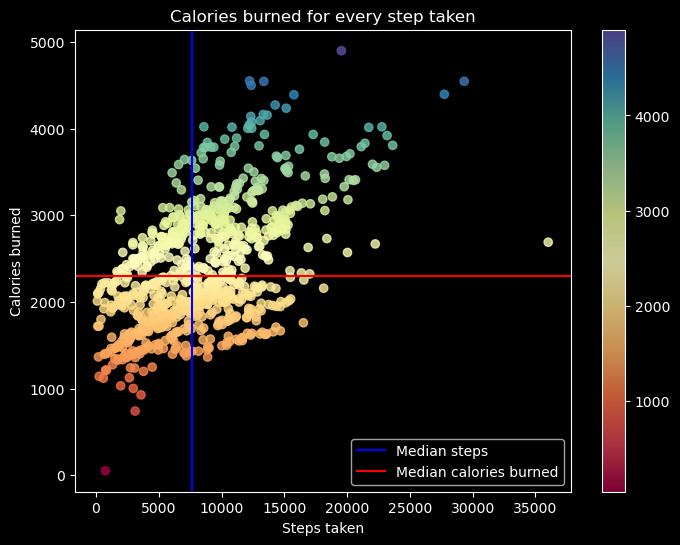

```python
# plotting scatter plot
plt.style.use(['dark_background'])
plt.figure(figsize=(8,6)) # specify size of the chart
plt.scatter(activity.TotalSteps, activity.Calories,
            alpha = 0.8, c = activity.Calories,
            cmap = "Spectral")

# add annotations and visuals
median_calories = 2303
median_steps = 7637

plt.colorbar(orientation = "vertical")
plt.axvline(median_steps, color = "Blue", label = "Median steps")
plt.axhline(median_calories, color = "Red", label = "Median calories burned")
plt.xlabel("Steps taken")
plt.ylabel("Calories burned")
plt.title("Calories burned for every step taken")
plt.grid(False)
plt.legend()
plt.show()
```

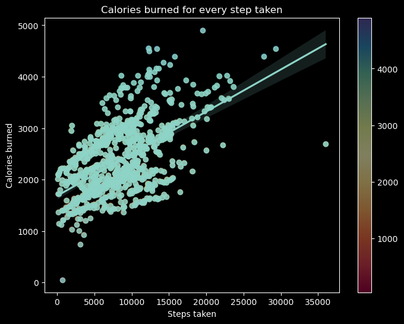

```python
plt.style.use(['dark_background'])
plt.figure(figsize=(8,6)) # specify size of the chart
plt.scatter(activity.TotalSteps, activity.Calories,
            alpha = 0.5, c = activity.Calories,
            cmap = "Spectral")
x=activity.TotalSteps
y=activity.Calories
sns.regplot(x, y)

# add annotations and visuals
median_calories = 2303
median_steps = 7637

plt.colorbar(orientation = "vertical")

plt.xlabel("Steps taken")
plt.ylabel("Calories burned")
plt.title("Calories burned for every step taken")
plt.grid(False)
plt.show()
```

##### **Calories burned for every step taken**

From the scatter plot, we discovered that:

[figure not shown]

```python
# import matplotlib package
import matplotlib.pyplot as plt

# plotting scatter plot
plt.style.use(["dark_background"])
plt.figure(figsize=(8,6)) # Specify size of the chart
plt.scatter(activity.TotalHours, activity.Calories,
            alpha = 0.8, c = activity.Calories,
            cmap = "Spectral")

# adding annotations and visuals
median_calories = 2303
median_hours = 20
median_sedentary = 991 / 60

plt.colorbar(orientation = "vertical")
plt.axvline(median_hours, color = "Blue", label = "Median steps")
plt.axvline(median_sedentary, color = "Purple", label = "Median sedentary")
plt.axhline(median_calories, color = "Red", label = "Median hours")
plt.xlabel("Hours logged")
plt.ylabel("Calories burned")
plt.title("Calories burned for every hour logged")
plt.legend()
plt.grid(False)
plt.show()
```

##### **Calories burned for every hour logged**

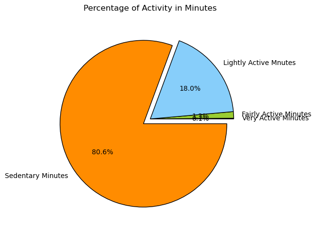

```python
# import packages
import matplotlib.pyplot as plt
import numpy as np

# calculating total of individual minutes column
VeryActiveMinutes = activity["VeryActiveDistance"].sum()
FairlyActiveMinutes = activity["FairlyActiveMinutes"].sum()
LightlyActiveMinutes = activity["LightlyActiveMinutes"].sum()
SedentaryMinutes = activity["SedentaryMinutes"].sum()

# plotting pie chart
slices = [VeryActiveMinutes, FairlyActiveMinutes, LightlyActiveMinutes, SedentaryMinutes]
labels = ["Very Active Minutes", "Fairly Active Minutes", "Lightly Active Mnutes", "Sedentary Minutes"]
colours = ["lightcoral", "yellowgreen", "lightskyblue", "darkorange"]
explode = [0, 0, 0, 0.1]
plt.style.use("default")
plt.pie(slices,
        labels = labels,
        colors = colours,
        wedgeprops = {"edgecolor": "black"},
        explode = explode,
        autopct = "%1.1f%%")

plt.title("Percentage of Activity in Minutes")
plt.tight_layout()
plt.show()
```

**Percentage of Activity in Minutes**

### Sleep dataset

Let's move ahead and look into sleep related data.

```python
SleepDay.sample(2)
```

|  | Id | SleepDay | TotalSleepRecords | TotalMinutesAsleep | TotalTimeInBed |
| --- | --- | --- | --- | --- | --- |
| 0 | 1503960366 | 4/12/2016 12:00:00 AM | 1 | 327 | 346 |
| 54 | 2026352035 | 5/1/2016 12:00:00 AM | 1 | 527 | 546 |

```python
SleepDay.info()
```

```
<class 'pandas.core.frame.DataFrame'>
RangeIndex: 413 entries, 0 to 412
Data columns (total 5 columns):
 #   Column              Non-Null Count  Dtype
---  ------              --------------  -----
 0   Id                  413 non-null    int64
 1   SleepDay            413 non-null    object
 2   TotalSleepRecords   413 non-null    int64
 3   TotalMinutesAsleep  413 non-null    int64
 4   TotalTimeInBed      413 non-null    int64
dtypes: int64(4), object(1)
memory usage: 16.3+ KB
```

```python
SleepDay.isnull().sum()
```

```
Id                    0
SleepDay              0
TotalSleepRecords     0
TotalMinutesAsleep    0
TotalTimeInBed        0
dtype: int64
```

```python
SleepDay['Date']= pd.to_datetime(SleepDay['SleepDay'])
SleepDay.drop(labels=['SleepDay'], axis=1, inplace = True)
SleepDay
```

|  | Id | TotalSleepRecords | TotalMinutesAsleep | TotalTimeInBed | Date |
| --- | --- | --- | --- | --- | --- |
| 0 | 1503960366 | 1 | 327 | 346 | 2016-04-12 |
| 1 | 1503960366 | 2 | 384 | 407 | 2016-04-13 |
| 2 | 1503960366 | 1 | 412 | 442 | 2016-04-15 |
| 3 | 1503960366 | 2 | 340 | 367 | 2016-04-16 |
| 4 | 1503960366 | 1 | 700 | 712 | 2016-04-17 |
| ... | ... | ... | ... | ... | ... |
| 408 | 8792009665 | 1 | 343 | 360 | 2016-04-30 |
| 409 | 8792009665 | 1 | 503 | 527 | 2016-05-01 |
| 410 | 8792009665 | 1 | 415 | 423 | 2016-05-02 |
| 411 | 8792009665 | 1 | 516 | 545 | 2016-05-03 |
| 412 | 8792009665 | 1 | 439 | 463 | 2016-05-04 |

413 rows × 5 columns

Below you find the column explanations according to FitBit's data dictionary (https://www.fitabase.com/media/1748/fitabasedatadictionary.pdf):

- TotalSleepRecords: Number of recorded sleep records for that day
- TotalTimeinBed: Total minutes spent in bed, including awake, light, deep, and REM sleep, during a defined sleep record
- TotalMinutesAsleep: Total number of minutes classified as being “asleep” sum total of light, deep, and REM sleep

```python
SleepDay.describe()
```

|  | Id | TotalSleepRecords | TotalMinutesAsleep | TotalTimeInBed |
| --- | --- | --- | --- | --- |
| count | 4.130000e+02 | 413.000000 | 413.000000 | 413.000000 |
| mean | 5.000979e+09 | 1.118644 | 419.467312 | 458.639225 |
| std | 2.060360e+09 | 0.345521 | 118.344679 | 127.101607 |
| min | 1.503960e+09 | 1.000000 | 58.000000 | 61.000000 |
| 25% | 3.977334e+09 | 1.000000 | 361.000000 | 403.000000 |
| 50% | 4.702922e+09 | 1.000000 | 433.000000 | 463.000000 |
| 75% | 6.962181e+09 | 1.000000 | 490.000000 | 526.000000 |
| max | 8.792010e+09 | 3.000000 | 796.000000 | 961.000000 |

```python
SleepDay['Id'].nunique()
```

```
24
```

- The dataset doesn't contain any null values
- The dataset consists of 413 entries out of 1023 maximum possible entries (40.4%)
- Only 24 users show any sleep data (some people might not have worn the device at night due to charging or other reasons).
- The maximum TotalMinutesAsleep value is 796 minutes or 13.3 hours. Probably that user has slept for several times a days which can be verified later.
- Minimum TotalMinutesAsleep is 58 minutes.

```python
SleepDay[SleepDay['TotalMinutesAsleep'] > 600]
```

|  | Id | TotalSleepRecords | TotalMinutesAsleep | TotalTimeInBed | Date |
| --- | --- | --- | --- | --- | --- |
| 4 | 1503960366 | 1 | 700 | 712 | 2016-04-17 |
| 27 | 1644430081 | 1 | 796 | 961 | 2016-05-02 |
| 29 | 1844505072 | 1 | 644 | 961 | 2016-04-15 |
| 30 | 1844505072 | 1 | 722 | 961 | 2016-04-30 |
| 32 | 1927972279 | 3 | 750 | 775 | 2016-04-12 |
| 125 | 4319703577 | 1 | 692 | 722 | 2016-04-23 |
| 138 | 4319703577 | 1 | 602 | 638 | 2016-05-08 |
| 145 | 4388161847 | 2 | 619 | 641 | 2016-04-17 |
| 232 | 5553957443 | 2 | 651 | 686 | 2016-04-16 |
| 236 | 5553957443 | 1 | 658 | 678 | 2016-04-20 |
| 239 | 5553957443 | 2 | 631 | 725 | 2016-04-23 |
| 246 | 5553957443 | 2 | 775 | 843 | 2016-04-30 |
| 247 | 5553957443 | 2 | 622 | 686 | 2016-05-01 |
| 281 | 5577150313 | 1 | 603 | 634 | 2016-05-04 |
| 299 | 6117666160 | 2 | 658 | 698 | 2016-05-06 |
| 307 | 6962181067 | 3 | 630 | 679 | 2016-04-13 |
| 347 | 7086361926 | 1 | 681 | 704 | 2016-04-24 |
| 370 | 8378563200 | 2 | 611 | 689 | 2016-04-16 |

There are 18 records where the user slept longer than 10 hours. 50% of the users slept several times a day (TotalSleepRecords > 1).

- **Let's calculate the time users are awake while in bed**

```python
SleepDay['wake_time']= SleepDay['TotalTimeInBed']-SleepDay['TotalMinutesAsleep']
SleepDay.groupby('Id').mean()
```

| Id | TotalSleepRecords | TotalMinutesAsleep | TotalTimeInBed | wake_time |
| --- | --- | --- | --- | --- |
| 1503960366 | 1.080000 | 360.280000 | 383.200000 | 22.920000 |
| 1644430081 | 1.000000 | 294.000000 | 346.000000 | 52.000000 |
| 1844505072 | 1.000000 | 652.000000 | 961.000000 | 309.000000 |
| 1927972279 | 1.600000 | 417.000000 | 437.800000 | 20.800000 |
| 2026352035 | 1.000000 | 506.178571 | 537.642857 | 31.464286 |
| 2320127002 | 1.000000 | 61.000000 | 69.000000 | 8.000000 |
| 2347167796 | 1.000000 | 446.800000 | 491.333333 | 44.533333 |
| 3977333714 | 1.142857 | 293.642857 | 461.142857 | 167.500000 |
| 4020332650 | 1.000000 | 349.375000 | 379.750000 | 30.375000 |
| 4319703577 | 1.038462 | 476.653846 | 501.961538 | 25.307692 |
| 4388161847 | 1.291667 | 403.125000 | 426.208333 | 23.083333 |
| 4445114986 | 1.392857 | 385.178571 | 416.821429 | 31.642857 |
| 4558609924 | 1.000000 | 127.600000 | 140.000000 | 12.400000 |
| 4702921684 | 1.071429 | 421.142857 | 441.964286 | 20.821429 |
| 5553957443 | 1.225806 | 463.483871 | 505.870968 | 42.387097 |
| 5577150313 | 1.038462 | 432.000000 | 460.615385 | 28.615385 |
| 6117666160 | 1.222222 | 478.777778 | 510.166667 | 31.388889 |
| 6775888955 | 1.000000 | 349.666667 | 369.000000 | 19.333333 |
| 6962181067 | 1.096774 | 448.000000 | 466.129032 | 18.129032 |
| 7007744171 | 1.000000 | 68.500000 | 71.500000 | 3.000000 |
| 7086361926 | 1.000000 | 453.125000 | 466.416667 | 13.291667 |
| 8053475328 | 1.000000 | 297.000000 | 301.666667 | 4.666667 |
| 8378563200 | 1.125000 | 443.343750 | 483.312500 | 39.968750 |
| 8792009665 | 1.000000 | 435.666667 | 453.800000 | 18.133333 |

FitBit calculates time asleep based on a combination of movement and heart-rate patterns (https://help.fitbit.com/articles/en_US/Help_article/2163.htm). If we compare time in bed with the actual time asleep, the gap might indicate the user is:

- restless and cannot fall asleep
- is still awake (e.g. reading or using the phone)
- woke-up (several times) during sleep
- doesn't get up immediately the next morning.

It's difficult to attribute the exact reason for this. In general the gap between both values varies quite a lot.

```python
SleepDay['Day'] = SleepDay['Date'].dt.day
SleepDay['Month'] = SleepDay['Date'].dt.month
SleepDay['Year'] = SleepDay['Date'].dt.year
```

```python
SleepDay.sample(2)
```

|  | Id | TotalSleepRecords | TotalMinutesAsleep | TotalTimeInBed | Date | wake_time | Day | Month | Year |
| --- | --- | --- | --- | --- | --- | --- | --- | --- | --- |
| 297 | 6117666160 | 1 | 507 | 575 | 2016-05-01 | 68 | 1 | 5 | 2016 |
| 55 | 2026352035 | 1 | 511 | 543 | 2016-05-02 | 32 | 2 | 5 | 2016 |

```python
SleepDay.Year.unique()
```

```
array([2016], dtype=int64)
```

```python
SleepDay.Day.unique()
```

```
array([12, 13, 15, 16, 17, 19, 20, 21, 23, 24, 25, 26, 28, 29, 30,  1,  2,
        3,  5,  6,  7,  8,  9, 10, 11, 14, 22, 27,  4, 18], dtype=int64)
```

```python
SleepDay.Month.unique()
```

```
array([4, 5], dtype=int64)
```

```python
SleepDay['DayName']=SleepDay.Date.dt.day_name()
SleepDay['DayName'].unique()
```

```
array(['Tuesday', 'Wednesday', 'Friday', 'Saturday', 'Sunday', 'Thursday',
       'Monday'], dtype=object)
```

```python
SleepDay['MonthName']=SleepDay['Month'].apply(lambda x: calendar.month_abbr[x])
SleepDay['MonthName'].unique()
```

```
array(['Apr', 'May'], dtype=object)
```

```python
SleepDay.sample(3)
```

|  | Id | TotalSleepRecords | TotalMinutesAsleep | TotalTimeInBed | Date | wake_time | Day | Month | Year | DayName | MonthName |
| --- | --- | --- | --- | --- | --- | --- | --- | --- | --- | --- | --- |
| 175 | 4445114986 | 1 | 436 | 469 | 2016-04-21 | 33 | 21 | 4 | 2016 | Thursday | Apr |
| 113 | 4020332650 | 1 | 226 | 248 | 2016-05-05 | 22 | 5 | 5 | 2016 | Thursday | May |
| 371 | 8378563200 | 2 | 525 | 591 | 2016-04-17 | 66 | 17 | 4 | 2016 | Sunday | Apr |

- **Let's merge the `SleepDay` dataframe with the `activity` dataframe and check how the activity intensity impacts sleep duration.**

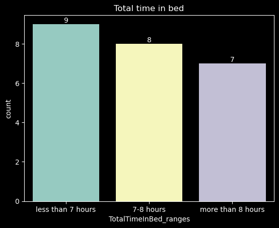

```python
data = SleepDay.groupby('Id').mean().reset_index()
#create a function that groups users in 3 categories: sleep <7 hours, sleep 7-8 hours, sleep >8 hours
def assign_ranges(x):
    if x<420:
        return "less than 7 hours"
    elif x>=420 and x<480:
        return "7-8 hours"
    else:
        return "more than 8 hours"
#use lambda function to create a new column based on ranges
data['TotalTimeInBed_ranges'] = data['TotalTimeInBed'].apply(lambda x: assign_ranges(x))
a=sns.countplot(x="TotalTimeInBed_ranges", data=data, order=["less than 7 hours", "7-8 hours", "more than 8 hours"]);
a.bar_label(a.containers[0], fontsize=10)

plt.title('Total time in bed');
```

- **Let's merge the data with the activity dataframe and check how the intensities affect the sleep behavior.**

```python
data2 = activity.groupby(['Id']).mean().reset_index()

# merge both dataframes based on Id column, only Ids common in both dataframes remain
merged_data = pd.merge(data2, data, on="Id")
merged_data.head(5)
```

|  | Id | Day_x | Month_x | Year_x | TotalSteps | TrackerDistance | LoggedActivitiesDistance | VeryActiveDistance | ModeratelyActiveDistance | LightActiveDistance | ... | TotalMinutes | TotalHours | TotalSleepRecords | TotalMinutesAsleep | TotalTimeInBed | wake_time | Day_y | Month_y | Year_y | TotalTimeInBed_ranges |
| --- | --- | --- | --- | --- | --- | --- | --- | --- | --- | --- | --- | --- | --- | --- | --- | --- | --- | --- | --- | --- | --- |
| 0 | 1503960366 | 2.900000 | 2.900000 | 2016.0 | 12520.633333 | 8.070000 | 0.0 | 2.953667 | 0.820667 | 4.291333 | ... | 1115.500000 | 18.600000 | 1.08 | 360.280000 | 383.200000 | 22.920000 | 15.200000 | 4.400000 | 2016.0 | less than 7 hours |
| 1 | 1644430081 | 2.900000 | 2.900000 | 2016.0 | 7282.966667 | 5.295333 | 0.0 | 0.730000 | 0.951000 | 3.609000 | ... | 1371.266667 | 22.866667 | 1.00 | 294.000000 | 346.000000 | 52.000000 | 17.250000 | 4.500000 | 2016.0 | less than 7 hours |
| 2 | 1844505072 | 3.222222 | 3.222222 | 2016.0 | 4440.333333 | 2.936111 | 0.0 | 0.014444 | 0.084444 | 2.835000 | ... | 1279.833333 | 21.333333 | 1.00 | 652.000000 | 961.000000 | 309.000000 | 15.333333 | 4.333333 | 2016.0 | more than 8 hours |
| 3 | 1927972279 | 2.764706 | 2.764706 | 2016.0 | 1670.588235 | 1.157059 | 0.0 | 0.174706 | 0.057059 | 0.924706 | ... | 1318.529412 | 22.000000 | 1.60 | 417.000000 | 437.800000 | 20.800000 | 18.800000 | 4.000000 | 2016.0 | 7-8 hours |
| 4 | 2026352035 | 2.903226 | 2.903226 | 2016.0 | 5566.870968 | 3.454839 | 0.0 | 0.006129 | 0.011290 | 3.436129 | ... | 946.419355 | 15.838710 | 1.00 | 506.178571 | 537.642857 | 31.464286 | 15.357143 | 4.392857 | 2016.0 | more than 8 hours |

5 rows × 26 columns

```python
merged_data.columns
```

```
Index(['Id', 'Day_x', 'Month_x', 'Year_x', 'TotalSteps', 'TrackerDistance',
       'LoggedActivitiesDistance', 'VeryActiveDistance',
       'ModeratelyActiveDistance', 'LightActiveDistance',
       'SedentaryActiveDistance', 'VeryActiveMinutes', 'FairlyActiveMinutes',
       'LightlyActiveMinutes', 'SedentaryMinutes', 'Calories', 'TotalMinutes',
       'TotalHours', 'TotalSleepRecords', 'TotalMinutesAsleep',
       'TotalTimeInBed', 'wake_time', 'Day_y', 'Month_y', 'Year_y',
       'TotalTimeInBed_ranges'],
      dtype='object')
```

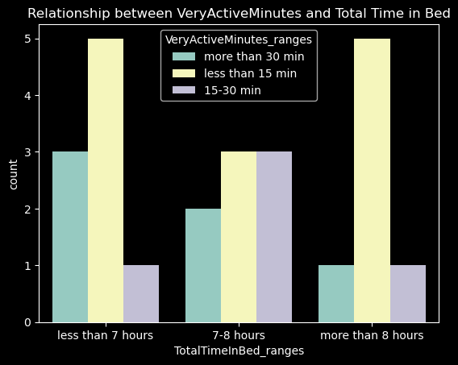

```python
def assign_ranges2(x):
    if x<15:
        return "less than 15 min"
    elif x>=15 and x<30:
        return "15-30 min"
    else:
        return "more than 30 min"
#use lambda function to create a new column based on ranges
merged_data['VeryActiveMinutes_ranges'] = merged_data['VeryActiveMinutes'].apply(lambda x: assign_ranges2(x))
merged_data
b=sns.countplot(x='TotalTimeInBed_ranges',
                data=merged_data,
                hue='VeryActiveMinutes_ranges',
                order=['less than 7 hours', '7-8 hours', 'more than 8 hours'])
b.bar_label(a.containers[0], fontsize=10)

plt.title('Relationship between VeryActiveMinutes and Total Time in Bed');
```

```python
new = merged_data[['TotalSteps','Calories','TotalMinutesAsleep','TotalTimeInBed','wake_time','VeryActiveMinutes_ranges']]
new.groupby('VeryActiveMinutes_ranges').mean()
```

| VeryActiveMinutes_ranges | TotalSteps | Calories | TotalMinutesAsleep | TotalTimeInBed | wake_time |
| --- | --- | --- | --- | --- | --- |
| 15-30 min | 8859.965349 | 2155.724462 | 391.583679 | 445.670238 | 54.086559 |
| less than 15 min | 6073.170223 | 2235.844710 | 388.567176 | 437.480008 | 48.912832 |
| more than 30 min | 11197.219438 | 2840.991740 | 342.374792 | 361.118536 | 18.743745 |

It is pretty obvious that people who are very active for more than 30 min accumulate the highest number of average calories. In average this group only sleeps for 6 hours a day with the lowest awake time. For the other two groups (which are very active for less than 15 min and 15-30 min) total minutes asleep and awake time are almost similar.

# Summary

- The data shows a huge variation among the users in terms of measured features: daily steps, calories, intensities, etc.
- For 15.6% of the observed time period there is no data available (in reality this period could be even bigger since the users were paid for their data via Amazon Mechanical Turk which might have incentivized them)
- Only 24 out of 33 users provide any sleep related data (device wasn't worn at night or didn't support this feature) which only covers 40.4% of all possible observations
- Users do not log their activity for the majority of the time
- Only 8 out 33 users provided any weight related data. 3 out of these 8 probably have a scale that automatically connects to the FitBit device.
- Tuesday and Saturday have the highest average step number as well as calorie consumption. Friday and Sunday are those with the lowest.
- On weekends people are most active from 12-3pm. During the week from 5-8pm (which is probably for most people after work).
- There is only a weak correlation between daily steps and calories, but a high correlation between veryactiveminutes and calories and veryactiveminutes and tracker distance
- Users who were very active for more than 30 minutes per day accumulated the highest amount of calories but also slept the lowest amount of time (approx. 6 hours) and shortest awake time
- Body fat was only measured correctly twice (if not caused by data manipulation), sedentarydistance was sometimes incorrect (>0)

In the final step, we will be delivering our insights and providing recommendations based on our analysis.

Here, we revisit our business questions and share with you our high-level business recommendations.

**2. How could these trends apply to Bellabeat customers?**

- Both companies develop products focused on providing women with their health, habit and fitness data and encouraging them to understand their current habits and make healthy decisions. These common trends surrounding health and fitness can very well abe pplied to Bellabeat customers.

**3. How could these trends help influence Bellabeat marketing strategy?**

- Bellabeat marketing team can encourage users by educating and equipping them with knowledge about fitness benefits, suggest different types of exercise (ie. simple 10 minutes exercise on weekday and a more intense exercise on weekends) and calories intake and burnt rate information on the Bellabeat app.
- On weekends, Bellabeat app can also prompt notification to encourage users to exercise.

## Recommendations

**The following findings/hints should be verified by another/new dataset with more transparency about the data collection method.**

- Offer more customization possibilities to users. Data shows huge variation among user features (average steps, workout intensities, weight, etc.). Different user groups require different motivations, programs, etc. A more targeted approach might improve customer retention.
- Improved battery life or charging recommendations could help that people wear the device more often.
- Automated tracking of activities instead of manual input (FitBit data shows that if scale is connected to FitBit automatically it might increase the likelihood to receive weight data which can offer more detailed analysis and recommendations to the user). Algorithms allow today to automatically detect activites (such as running, swimming, cycling).
- Instead of manual input, additional user information could be automatically detected by face recognition in the Bellabeat app if the user consent has been obtained, e.g. detect gender, age, BMI based on camera, similar as Anura app)
- Reminders on the phone, participation in competitions (social) or goal-setting could help increase the user's engagement
- Due to the very small screen of the wearable, the user faces difficulties to navigate through the settings,therefore user experience is key --> automation and accessibility for users with bad eyes, etc. should be ensured (bigger fonts, simplified menu, enlarged icons, etc.)
- It seems there were some technical issues indicated by the data (low number of steps on certain days, sedentarydistance, body fat, etc.). It is important that the device is reliable

**A few findings from other studies can be found below which are partly supported by findings from the FitBit dataset:**

- Many users are not satisfied with the usability
- The longer the device is used, the more satisfactory the users are (especially health professionals)
- Users show a low brand loyalty
- Strong use cases strengthen usage of device such as people with health problems (diabetes, high blood pressure) or athletes
- Intelligent recognition functions are required (e.g. algorithms which can track activity automatically)
- Comfort, charging burdens and functions are key areas to focus on
- Most devices show similar functions, therefore new technologies could offer a competitive advantage by new features